# Challenge 7

Take a newspaper. Take a pair of scissors . . .

Kyeri Kim

10/23/2019

# Challenge 7

The goal of this challenge is to synthesize what you have learned about R and DADA2 to generate a phyloseq object from the map file and the demultiplexed FASTQs that you generated in Challenge 6. You will find this [overview of the DADA2 pipeline](https://github.com/ibiem-2019/ibiem_2019_material/blob/master/content/lessons/dada2_pipeline_toc.md) very helpful in completing this assignment.

You will find the FASTQs, map file, and an md5 checksum file in `/data/tutorial_data/ibiem2016_subset`. The name of the map file is `ibiem_2017_map_v3.txt`

You must fill in the chunks below as indicated, but you are free to add other chunks too. To submit this assignment for full credit you should *commit* and *push*:

1. This file (`challenge7.Rmd`)
2. The knited version of this file (`challenge7.html`)

These are the *ONLY* files you should include in your repo. I strongly recommend that you make a `scratch` subdirectory in your home directory, then make subdirectories for each project in scratch, for example `~/scratch/challenge7`. If you don’t follow this advice, but instead put temporary files in your repo directory, you *must* be sure not to commit them to your repo, you will lose points if you do.

# Setup

## Load Libraries

```r
library(dada2)
library(readr)
library(stringr)
library(dplyr)
```

```r
library(tibble)
library(magrittr)
library(phyloseq)
library(ggplot2)
library(fs)
```

## Paths, Directories, and Shell Variables

To keep the code readable and portable, it is nice to assign paths to variables.

```r
output.dir = path.expand("/home/guest/project1_ibiem/demultiplexed")
demux.dir = file.path(path.expand("/home/guest/project1_ibiem/demultiplexed"), "demux")
```

```r
scratch.dir = file.path(output.dir, "dada2")

data.dir = "/home/guest/project1_ibiem/rawdata/argonne_data"
map.file = file.path(data.dir,"200114_McCumber_16SFW_AS_200110.txt")

# output directory
if (dir_exists(scratch.dir)) {
  dir_delete(scratch.dir)
}
dir_create(scratch.dir)

ps.rds = file.path(scratch.dir, "ibiemProject1_subset.rds")

# NOT SURE IF WE USE THIS REFERENCES FOR OUR PROJECT YET
silva.ref = "/data/references/dada/silva_nr_v132_train_set.fa.gz"
silva.species.ref = "/data/references/dada/silva_species_assignment_v132.fa.gz"
```

## Checking Files

Let’s make sure that our demultiplexed files are all where we expect them

```r
list.files(demux.dir)
```

```
##   [1] "1_1.Undetermined_S0_L001_R1_001.fastq.gz"
##   [2] "1_1.Undetermined_S0_L001_R2_001.fastq.gz"
##   [3] "1_10.Undetermined_S0_L001_R1_001.fastq.gz"
##   [4] "1_10.Undetermined_S0_L001_R2_001.fastq.gz"
##   [5] "1_11.Undetermined_S0_L001_R1_001.fastq.gz"
##   [6] "1_11.Undetermined_S0_L001_R2_001.fastq.gz"
##   [7] "1_12.Undetermined_S0_L001_R1_001.fastq.gz"
##   [8] "1_12.Undetermined_S0_L001_R2_001.fastq.gz"
##   [9] "1_13.Undetermined_S0_L001_R1_001.fastq.gz"
##  [10] "1_13.Undetermined_S0_L001_R2_001.fastq.gz"
##  [11] "1_14.Undetermined_S0_L001_R1_001.fastq.gz"
##  [12] "1_14.Undetermined_S0_L001_R2_001.fastq.gz"
##  [13] "1_15.Undetermined_S0_L001_R1_001.fastq.gz"
##  [14] "1_15.Undetermined_S0_L001_R2_001.fastq.gz"
##  [15] "1_16.Undetermined_S0_L001_R1_001.fastq.gz"
```

[output cut: 245 more lines]

## Filter and Trim

First we read in the names of the fastq files, and perform some string manipulation to get lists of the forward and reverse fastq files in matched order. We also need to generate a vector of sample names from one of these lists of fastq file paths.

```r
fnFs <- sort(list.files(demux.dir, pattern="R1_001.fastq", full.names = TRUE))
fnRs <- sort(list.files(demux.dir, pattern="R2_001.fastq", full.names = TRUE))

forward_fastq_suffix = ".Undetermined_S0_L001_R1_001.fastq.gz"

sample.names = fnFs %>%
  basename %>%
  str_replace(forward_fastq_suffix,"")
```

Look at the list of “forward” FASTQs to be sure it only contains R1 files

```r
print(fnFs)
```

```
##   [1] "/home/guest/project1_ibiem/demultiplexed/demux/1_1.Undetermined_S0_L001_R1_001.fastq.gz"
##   [2] "/home/guest/project1_ibiem/demultiplexed/demux/1_10.Undetermined_S0_L001_R1_001.fastq.gz"
##   [3] "/home/guest/project1_ibiem/demultiplexed/demux/1_11.Undetermined_S0_L001_R1_001.fastq.gz"
##   [4] "/home/guest/project1_ibiem/demultiplexed/demux/1_12.Undetermined_S0_L001_R1_001.fastq.gz"
##   [5] "/home/guest/project1_ibiem/demultiplexed/demux/1_13.Undetermined_S0_L001_R1_001.fastq.gz"
##   [6] "/home/guest/project1_ibiem/demultiplexed/demux/1_14.Undetermined_S0_L001_R1_001.fastq.gz"
##   [7] "/home/guest/project1_ibiem/demultiplexed/demux/1_15.Undetermined_S0_L001_R1_001.fastq.gz"
##   [8] "/home/guest/project1_ibiem/demultiplexed/demux/1_16.Undetermined_S0_L001_R1_001.fastq.gz"
##   [9] "/home/guest/project1_ibiem/demultiplexed/demux/1_2.Undetermined_S0_L001_R1_001.fastq.gz"
##  [10] "/home/guest/project1_ibiem/demultiplexed/demux/1_3.Undetermined_S0_L001_R1_001.fastq.gz"
##  [11] "/home/guest/project1_ibiem/demultiplexed/demux/1_4.Undetermined_S0_L001_R1_001.fastq.gz"
##  [12] "/home/guest/project1_ibiem/demultiplexed/demux/1_5.Undetermined_S0_L001_R1_001.fastq.gz"
##  [13] "/home/guest/project1_ibiem/demultiplexed/demux/1_6.Undetermined_S0_L001_R1_001.fastq.gz"
##  [14] "/home/guest/project1_ibiem/demultiplexed/demux/1_7.Undetermined_S0_L001_R1_001.fastq.gz"
##  [15] "/home/guest/project1_ibiem/demultiplexed/demux/1_8.Undetermined_S0_L001_R1_001.fastq.gz"
```

[output cut: 113 more lines]

Look at the list of “reverse” FASTQs to be sure it only contains R2 files

```r
print(fnRs)
```

```
##   [1] "/home/guest/project1_ibiem/demultiplexed/demux/1_1.Undetermined_S0_L001_R2_001.fastq.gz"
##   [2] "/home/guest/project1_ibiem/demultiplexed/demux/1_10.Undetermined_S0_L001_R2_001.fastq.gz"
##   [3] "/home/guest/project1_ibiem/demultiplexed/demux/1_11.Undetermined_S0_L001_R2_001.fastq.gz"
##   [4] "/home/guest/project1_ibiem/demultiplexed/demux/1_12.Undetermined_S0_L001_R2_001.fastq.gz"
##   [5] "/home/guest/project1_ibiem/demultiplexed/demux/1_13.Undetermined_S0_L001_R2_001.fastq.gz"
##   [6] "/home/guest/project1_ibiem/demultiplexed/demux/1_14.Undetermined_S0_L001_R2_001.fastq.gz"
##   [7] "/home/guest/project1_ibiem/demultiplexed/demux/1_15.Undetermined_S0_L001_R2_001.fastq.gz"
##   [8] "/home/guest/project1_ibiem/demultiplexed/demux/1_16.Undetermined_S0_L001_R2_001.fastq.gz"
##   [9] "/home/guest/project1_ibiem/demultiplexed/demux/1_2.Undetermined_S0_L001_R2_001.fastq.gz"
##  [10] "/home/guest/project1_ibiem/demultiplexed/demux/1_3.Undetermined_S0_L001_R2_001.fastq.gz"
##  [11] "/home/guest/project1_ibiem/demultiplexed/demux/1_4.Undetermined_S0_L001_R2_001.fastq.gz"
##  [12] "/home/guest/project1_ibiem/demultiplexed/demux/1_5.Undetermined_S0_L001_R2_001.fastq.gz"
##  [13] "/home/guest/project1_ibiem/demultiplexed/demux/1_6.Undetermined_S0_L001_R2_001.fastq.gz"
##  [14] "/home/guest/project1_ibiem/demultiplexed/demux/1_7.Undetermined_S0_L001_R2_001.fastq.gz"
##  [15] "/home/guest/project1_ibiem/demultiplexed/demux/1_8.Undetermined_S0_L001_R2_001.fastq.gz"
```

[output cut: 113 more lines]

```r
print(sample.names)
```

```
##   [1] "1_1"   "1_10"  "1_11"  "1_12"  "1_13"  "1_14"  "1_15"  "1_16"  "1_2"
##  [10] "1_3"   "1_4"   "1_5"   "1_6"   "1_7"   "1_8"   "1_9"   "12_1"  "12_10"
##  [19] "12_11" "12_12" "12_13" "12_14" "12_15" "12_16" "12_2"  "12_3"  "12_4"
##  [28] "12_5"  "12_6"  "12_7"  "12_8"  "12_9"  "2_1"   "2_10"  "2_11"  "2_12"
##  [37] "2_13"  "2_14"  "2_15"  "2_16"  "2_2"   "2_3"   "2_4"   "2_5"   "2_6"
##  [46] "2_7"   "2_8"   "2_9"   "3_1"   "3_10"  "3_11"  "3_12"  "3_13"  "3_14"
##  [55] "3_15"  "3_16"  "3_2"   "3_3"   "3_4"   "3_5"   "3_6"   "3_7"   "3_8"
##  [64] "3_9"   "4_1"   "4_10"  "4_11"  "4_12"  "4_13"  "4_14"  "4_15"  "4_16"
##  [73] "4_2"   "4_3"   "4_4"   "4_5"   "4_6"   "4_7"   "4_8"   "4_9"   "5_1"
##  [82] "5_10"  "5_11"  "5_12"  "5_13"  "5_14"  "5_15"  "5_16"  "5_2"   "5_3"
##  [91] "5_4"   "5_5"   "5_6"   "5_7"   "5_8"   "5_9"   "6_1"   "6_10"  "6_11"
## [100] "6_12"  "6_13"  "6_14"  "6_15"  "6_16"  "6_2"   "6_3"   "6_4"   "6_5"
## [109] "6_6"   "6_7"   "6_8"   "6_9"   "7_1"   "7_10"  "7_11"  "7_12"  "7_13"
## [118] "7_14"  "7_15"  "7_16"  "7_2"   "7_3"   "7_4"   "7_5"   "7_6"   "7_7"
## [127] "7_8"   "7_9"
```

## Examine quality profiles of forward and reverse reads

```r
list.files(data.dir)
```

```
## [1] "200114_McCumber_16SFW_AS_200110.txt"
## [2] "md5_checksum_compressed_fastqs.txt"
## [3] "md5_checksum_uncompressed_fastqs.txt"
## [4] "Undetermined_S0_L001_I1_001.fastq.gz"
## [5] "Undetermined_S0_L001_R1_001.fastq.gz"
## [6] "Undetermined_S0_L001_R2_001.fastq.gz"
```

## Forward Read Quality Profile

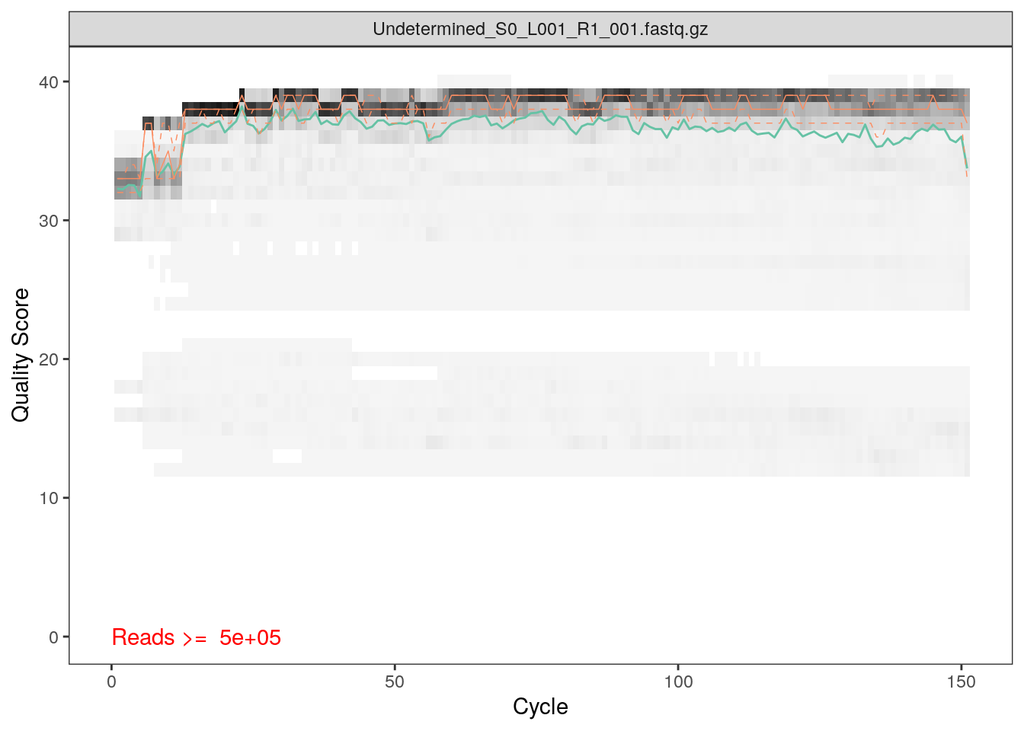

```r
plotQualityProfile(file.path(data.dir, "Undetermined_S0_L001_R1_001.fastq.gz"))
```

## Reverse Read Quality Profile

Now we visualize the quality profile of the reverse reads:

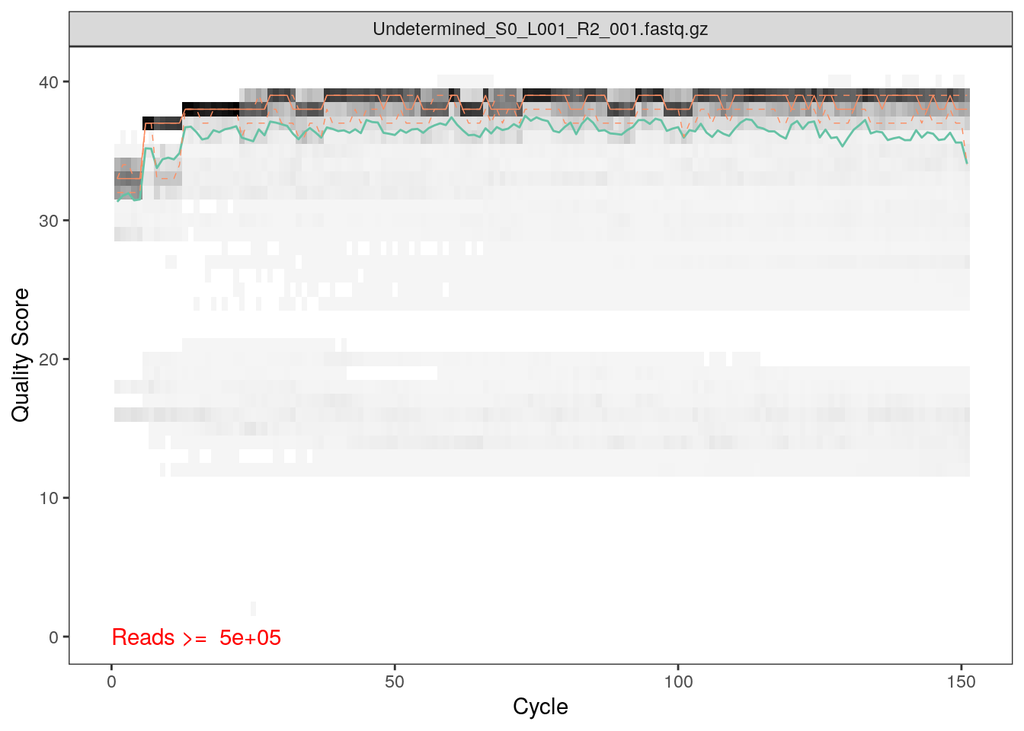

```r
plotQualityProfile(file.path(data.dir, "Undetermined_S0_L001_R2_001.fastq.gz"))
```

## Perform filtering and trimming

There a few things to note in selecting trimming parameters:

1. These reads are only *150bp*, which is shorter than the *250bp* reads in the MiSeqSOP dataset that is used in the official the DADA2 tutorial.
2. The quality does not drop off as dramatically at the 3’ ends of these reads as in 250bp reads (presumably because these are shorter).
3. The amplicon length is approximately 248 - 253bp.
4. We need to have at least 20bp overlap at the 3’ end for merging.

### Generate filenames for the filtered fastq.gz files.

You need to use the names of the raw (demultiplexed) FASTQ files to generate a vector of names for the filtered FASTQs. You need separate vectors for the forward and reverse reads. It is a very good idea to put all the filtered FASTQs in their own directory.

```r
#put all the filtered FASTQs in their own directory
filt_path <- file.path(scratch.dir, "filtered")

filtFs <- file.path(filt_path, paste0(sample.names, "_F_filt.fastq.gz"))
filtRs <- file.path(filt_path, paste0(sample.names, "_R_filt.fastq.gz"))
```

### Filter the forward and reverse reads

Now let’s do the filtering using the parameters we chose based on the quality plots

```r
filt.out <- filterAndTrim(fnFs, filtFs, fnRs, filtRs, trimLeft=10, truncLen=c(145,140),
              maxN=0, maxEE=c(2,2), truncQ=2, rm.phix=TRUE,
              compress=TRUE, multithread=FALSE)
```

```
## Creating output directory: /home/guest/project1_ibiem/demultiplexed/dada2/filtered
```

```r
head(filt.out)
```

```
##                                           reads.in reads.out
## 1_1.Undetermined_S0_L001_R1_001.fastq.gz     26668     26220
## 1_10.Undetermined_S0_L001_R1_001.fastq.gz    36842     36109
## 1_11.Undetermined_S0_L001_R1_001.fastq.gz    32485     31963
## 1_12.Undetermined_S0_L001_R1_001.fastq.gz    27818     27393
## 1_13.Undetermined_S0_L001_R1_001.fastq.gz    38432     37844
## 1_14.Undetermined_S0_L001_R1_001.fastq.gz    42475     41706
```

### Tweak Filtered FASTQ list

There are a few samples that have very few reads to start with and no reads after filtering. If a sample doesn’t have any reads after filtering, `filterAndTrim` doesn’t bother to make an empty filtered FASTQ. We need to manage this, because downstream steps will give us an error if we give them a list of filtered FASTQ filenames that contains names of files that don’t actually exist. We need to regenerate our list of filtered FASTQs based on the filtered FASTQ files that are actually present in the directory. We also need to regenerate `sample.names` from the list of filtered FASTQ files.

```r
filtFs = filtFs[file_exists(filtFs)]
filtRs = filtRs[file_exists(filtRs)]
```

## Learn the Error Rates

With that bit of cleanup done, we are ready to build an error model from the filtered FASTQs. We do this seperately for the R1 and R2 FASTQs, since they have different patterns of errors, as we have seen.

```r
errF <- learnErrors(filtFs, multithread=TRUE)
```

```
## 101196810 total bases in 749606 reads from 27 samples will be used for learning the error rates.
```

```r
errR <- learnErrors(filtRs, multithread=TRUE)
```

```
## 101826660 total bases in 783282 reads from 28 samples will be used for learning the error rates.
```

It is always worthwhile, as a sanity check if nothing else, to visualize the estimated error rates:

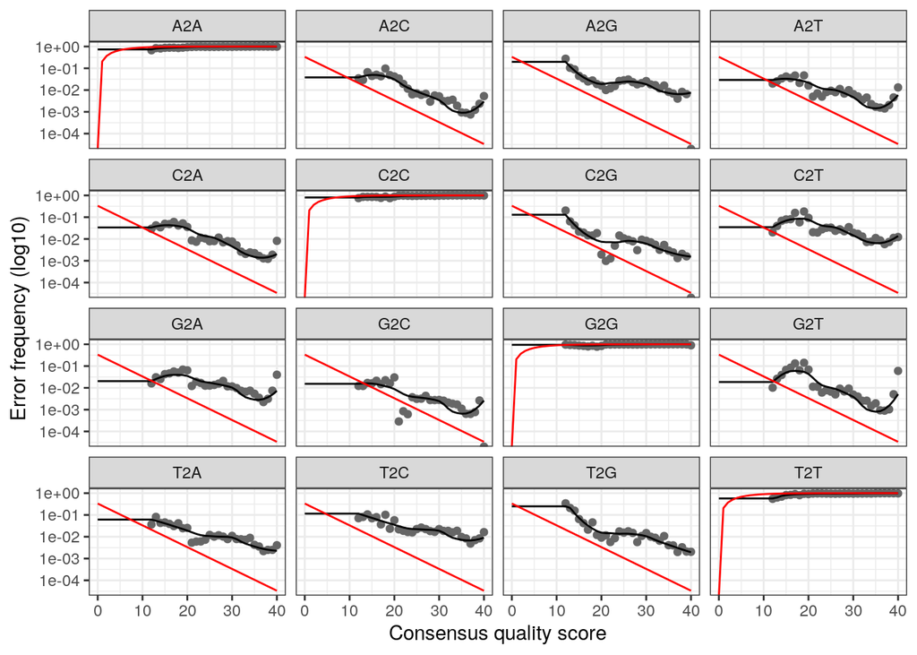

```r
plotErrors(errF, nominalQ=TRUE)
```

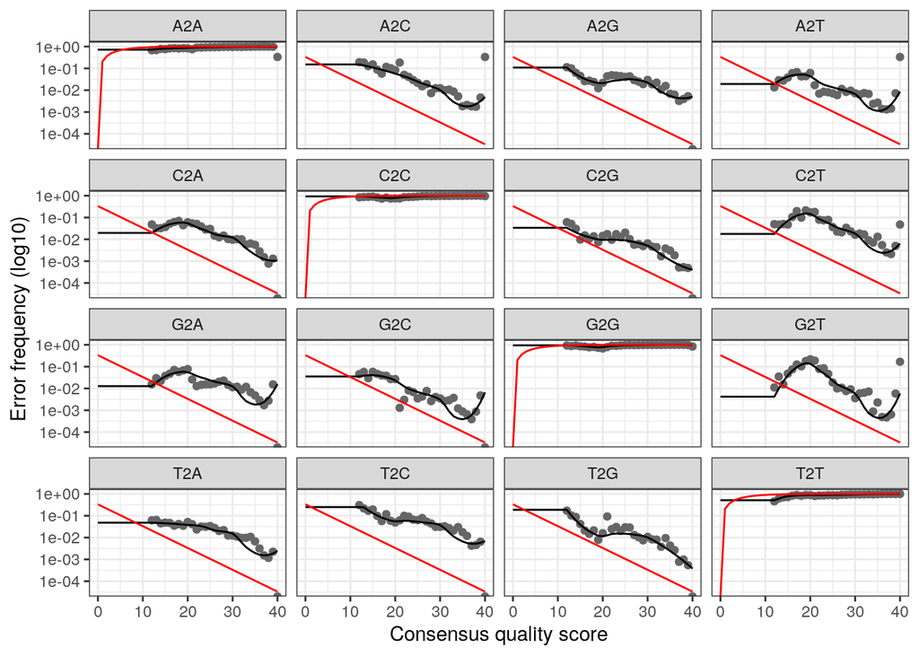

```r
plotErrors(errR, nominalQ=TRUE)
```

The error rates for each possible transition (eg. A->C, A->G, …) are shown. Points are the observed error rates for each consensus quality score. The black line shows the estimated error rates after convergence. The red line shows the error rates expected under the nominal definition of the Q-value. Here the black line (the estimated rates) fits the observed rates well, and the error rates drop with increased quality as expected.

Since we are using a small subset of the data, the learned error rates might look funny. This is OK for now, since we are just doing a pilot analysis.

## Dereplication

Dereplication combines all identical sequencing reads into into “unique sequences” with a corresponding “abundance” tally: the number of reads with that unique sequence. Dereplication substantially reduces computation time for the inference step, since we only need to do inference for unique sequences.

```r
filtFs %>%
  basename %>%
  str_replace("_F_filt.fastq.gz","") ->
  sample.names
derepFs <- derepFastq(filtFs, verbose=TRUE)
```

```
## Dereplicating sequence entries in Fastq file: /home/guest/project1_ibiem/demultiplexed/dada2/filtered/1_1_F_filt.fastq.gz
```

```
## Encountered 10159 unique sequences from 26220 total sequences read.
```

```
## Dereplicating sequence entries in Fastq file: /home/guest/project1_ibiem/demultiplexed/dada2/filtered/1_10_F_filt.fastq.gz
```

```
## Encountered 12476 unique sequences from 36109 total sequences read.
```

```
## Dereplicating sequence entries in Fastq file: /home/guest/project1_ibiem/demultiplexed/dada2/filtered/1_11_F_filt.fastq.gz
```

```
## Encountered 11142 unique sequences from 31963 total sequences read.
```

```
## Dereplicating sequence entries in Fastq file: /home/guest/project1_ibiem/demultiplexed/dada2/filtered/1_12_F_filt.fastq.gz
```

```
## Encountered 10078 unique sequences from 27393 total sequences read.
```

```
## Dereplicating sequence entries in Fastq file: /home/guest/project1_ibiem/demultiplexed/dada2/filtered/1_13_F_filt.fastq.gz
```

```
## Encountered 13500 unique sequences from 37844 total sequences read.
```

```
## Dereplicating sequence entries in Fastq file: /home/guest/project1_ibiem/demultiplexed/dada2/filtered/1_14_F_filt.fastq.gz
```

```
## Encountered 14316 unique sequences from 41706 total sequences read.
```

```
## Dereplicating sequence entries in Fastq file: /home/guest/project1_ibiem/demultiplexed/dada2/filtered/1_15_F_filt.fastq.gz
```

```
## Encountered 4247 unique sequences from 9613 total sequences read.
```

```
## Dereplicating sequence entries in Fastq file: /home/guest/project1_ibiem/demultiplexed/dada2/filtered/1_16_F_filt.fastq.gz
```

```
## Encountered 12370 unique sequences from 35803 total sequences read.
```

```
## Dereplicating sequence entries in Fastq file: /home/guest/project1_ibiem/demultiplexed/dada2/filtered/1_2_F_filt.fastq.gz
```

```
## Encountered 9352 unique sequences from 29414 total sequences read.
```

```
## Dereplicating sequence entries in Fastq file: /home/guest/project1_ibiem/demultiplexed/dada2/filtered/1_3_F_filt.fastq.gz
```

```
## Encountered 6559 unique sequences from 19520 total sequences read.
```

```
## Dereplicating sequence entries in Fastq file: /home/guest/project1_ibiem/demultiplexed/dada2/filtered/1_4_F_filt.fastq.gz
```

```
## Encountered 8342 unique sequences from 22542 total sequences read.
```

```
## Dereplicating sequence entries in Fastq file: /home/guest/project1_ibiem/demultiplexed/dada2/filtered/1_5_F_filt.fastq.gz
```

```
## Encountered 8875 unique sequences from 32074 total sequences read.
```

```
## Dereplicating sequence entries in Fastq file: /home/guest/project1_ibiem/demultiplexed/dada2/filtered/1_6_F_filt.fastq.gz
```

```
## Encountered 9791 unique sequences from 29539 total sequences read.
```

```
## Dereplicating sequence entries in Fastq file: /home/guest/project1_ibiem/demultiplexed/dada2/filtered/1_7_F_filt.fastq.gz
```

```
## Encountered 11432 unique sequences from 36077 total sequences read.
```

```
## Dereplicating sequence entries in Fastq file: /home/guest/project1_ibiem/demultiplexed/dada2/filtered/1_8_F_filt.fastq.gz
```

```
## Encountered 7351 unique sequences from 23472 total sequences read.
```

```
## Dereplicating sequence entries in Fastq file: /home/guest/project1_ibiem/demultiplexed/dada2/filtered/1_9_F_filt.fastq.gz
```

```
## Encountered 5164 unique sequences from 14602 total sequences read.
```

```
## Dereplicating sequence entries in Fastq file: /home/guest/project1_ibiem/demultiplexed/dada2/filtered/12_1_F_filt.fastq.gz
```

```
## Encountered 7887 unique sequences from 26751 total sequences read.
```

```
## Dereplicating sequence entries in Fastq file: /home/guest/project1_ibiem/demultiplexed/dada2/filtered/12_10_F_filt.fastq.gz
```

```
## Encountered 3522 unique sequences from 17023 total sequences read.
```

```
## Dereplicating sequence entries in Fastq file: /home/guest/project1_ibiem/demultiplexed/dada2/filtered/12_11_F_filt.fastq.gz
```

```
## Encountered 4420 unique sequences from 26135 total sequences read.
```

```
## Dereplicating sequence entries in Fastq file: /home/guest/project1_ibiem/demultiplexed/dada2/filtered/12_12_F_filt.fastq.gz
```

```
## Encountered 11393 unique sequences from 44996 total sequences read.
```

```
## Dereplicating sequence entries in Fastq file: /home/guest/project1_ibiem/demultiplexed/dada2/filtered/12_13_F_filt.fastq.gz
```

```
## Encountered 14030 unique sequences from 41751 total sequences read.
```

```
## Dereplicating sequence entries in Fastq file: /home/guest/project1_ibiem/demultiplexed/dada2/filtered/12_14_F_filt.fastq.gz
```

```
## Encountered 2869 unique sequences from 9350 total sequences read.
```

```
## Dereplicating sequence entries in Fastq file: /home/guest/project1_ibiem/demultiplexed/dada2/filtered/12_15_F_filt.fastq.gz
```

```
## Encountered 3909 unique sequences from 12892 total sequences read.
```

```
## Dereplicating sequence entries in Fastq file: /home/guest/project1_ibiem/demultiplexed/dada2/filtered/12_16_F_filt.fastq.gz
```

```
## Encountered 7635 unique sequences from 21447 total sequences read.
```

```
## Dereplicating sequence entries in Fastq file: /home/guest/project1_ibiem/demultiplexed/dada2/filtered/12_2_F_filt.fastq.gz
```

```
## Encountered 4869 unique sequences from 20806 total sequences read.
```

```
## Dereplicating sequence entries in Fastq file: /home/guest/project1_ibiem/demultiplexed/dada2/filtered/12_3_F_filt.fastq.gz
```

```
## Encountered 8789 unique sequences from 32708 total sequences read.
```

```
## Dereplicating sequence entries in Fastq file: /home/guest/project1_ibiem/demultiplexed/dada2/filtered/12_4_F_filt.fastq.gz
```

```
## Encountered 11959 unique sequences from 41856 total sequences read.
```

```
## Dereplicating sequence entries in Fastq file: /home/guest/project1_ibiem/demultiplexed/dada2/filtered/12_5_F_filt.fastq.gz
```

```
## Encountered 9584 unique sequences from 33676 total sequences read.
```

```
## Dereplicating sequence entries in Fastq file: /home/guest/project1_ibiem/demultiplexed/dada2/filtered/12_6_F_filt.fastq.gz
```

```
## Encountered 4802 unique sequences from 20012 total sequences read.
```

```
## Dereplicating sequence entries in Fastq file: /home/guest/project1_ibiem/demultiplexed/dada2/filtered/12_7_F_filt.fastq.gz
```

```
## Encountered 11710 unique sequences from 39483 total sequences read.
```

```
## Dereplicating sequence entries in Fastq file: /home/guest/project1_ibiem/demultiplexed/dada2/filtered/12_8_F_filt.fastq.gz
```

```
## Encountered 6776 unique sequences from 24997 total sequences read.
```

```
## Dereplicating sequence entries in Fastq file: /home/guest/project1_ibiem/demultiplexed/dada2/filtered/12_9_F_filt.fastq.gz
```

```
## Encountered 7101 unique sequences from 26348 total sequences read.
```

```
## Dereplicating sequence entries in Fastq file: /home/guest/project1_ibiem/demultiplexed/dada2/filtered/2_1_F_filt.fastq.gz
```

```
## Encountered 9276 unique sequences from 33886 total sequences read.
```

```
## Dereplicating sequence entries in Fastq file: /home/guest/project1_ibiem/demultiplexed/dada2/filtered/2_10_F_filt.fastq.gz
```

```
## Encountered 6620 unique sequences from 27641 total sequences read.
```

```
## Dereplicating sequence entries in Fastq file: /home/guest/project1_ibiem/demultiplexed/dada2/filtered/2_11_F_filt.fastq.gz
```

```
## Encountered 4265 unique sequences from 25197 total sequences read.
```

```
## Dereplicating sequence entries in Fastq file: /home/guest/project1_ibiem/demultiplexed/dada2/filtered/2_12_F_filt.fastq.gz
```

```
## Encountered 9905 unique sequences from 33705 total sequences read.
```

```
## Dereplicating sequence entries in Fastq file: /home/guest/project1_ibiem/demultiplexed/dada2/filtered/2_13_F_filt.fastq.gz
```

```
## Encountered 11327 unique sequences from 32552 total sequences read.
```

```
## Dereplicating sequence entries in Fastq file: /home/guest/project1_ibiem/demultiplexed/dada2/filtered/2_14_F_filt.fastq.gz
```

```
## Encountered 7146 unique sequences from 30809 total sequences read.
```

```
## Dereplicating sequence entries in Fastq file: /home/guest/project1_ibiem/demultiplexed/dada2/filtered/2_15_F_filt.fastq.gz
```

```
## Encountered 4801 unique sequences from 15574 total sequences read.
```

```
## Dereplicating sequence entries in Fastq file: /home/guest/project1_ibiem/demultiplexed/dada2/filtered/2_16_F_filt.fastq.gz
```

```
## Encountered 11354 unique sequences from 33473 total sequences read.
```

```
## Dereplicating sequence entries in Fastq file: /home/guest/project1_ibiem/demultiplexed/dada2/filtered/2_2_F_filt.fastq.gz
```

```
## Encountered 3913 unique sequences from 21118 total sequences read.
```

```
## Dereplicating sequence entries in Fastq file: /home/guest/project1_ibiem/demultiplexed/dada2/filtered/2_3_F_filt.fastq.gz
```

```
## Encountered 7713 unique sequences from 28939 total sequences read.
```

```
## Dereplicating sequence entries in Fastq file: /home/guest/project1_ibiem/demultiplexed/dada2/filtered/2_4_F_filt.fastq.gz
```

```
## Encountered 10121 unique sequences from 31481 total sequences read.
```

```
## Dereplicating sequence entries in Fastq file: /home/guest/project1_ibiem/demultiplexed/dada2/filtered/2_5_F_filt.fastq.gz
```

```
## Encountered 13536 unique sequences from 49797 total sequences read.
```

```
## Dereplicating sequence entries in Fastq file: /home/guest/project1_ibiem/demultiplexed/dada2/filtered/2_6_F_filt.fastq.gz
```

```
## Encountered 10033 unique sequences from 30253 total sequences read.
```

```
## Dereplicating sequence entries in Fastq file: /home/guest/project1_ibiem/demultiplexed/dada2/filtered/2_7_F_filt.fastq.gz
```

```
## Encountered 10511 unique sequences from 35572 total sequences read.
```

```
## Dereplicating sequence entries in Fastq file: /home/guest/project1_ibiem/demultiplexed/dada2/filtered/2_8_F_filt.fastq.gz
```

```
## Encountered 11981 unique sequences from 38247 total sequences read.
```

```
## Dereplicating sequence entries in Fastq file: /home/guest/project1_ibiem/demultiplexed/dada2/filtered/2_9_F_filt.fastq.gz
```

```
## Encountered 12241 unique sequences from 37875 total sequences read.
```

```
## Dereplicating sequence entries in Fastq file: /home/guest/project1_ibiem/demultiplexed/dada2/filtered/3_1_F_filt.fastq.gz
```

```
## Encountered 5225 unique sequences from 21393 total sequences read.
```

```
## Dereplicating sequence entries in Fastq file: /home/guest/project1_ibiem/demultiplexed/dada2/filtered/3_10_F_filt.fastq.gz
```

```
## Encountered 5254 unique sequences from 24538 total sequences read.
```

```
## Dereplicating sequence entries in Fastq file: /home/guest/project1_ibiem/demultiplexed/dada2/filtered/3_11_F_filt.fastq.gz
```

```
## Encountered 2958 unique sequences from 16746 total sequences read.
```

```
## Dereplicating sequence entries in Fastq file: /home/guest/project1_ibiem/demultiplexed/dada2/filtered/3_12_F_filt.fastq.gz
```

```
## Encountered 1731 unique sequences from 5602 total sequences read.
```

```
## Dereplicating sequence entries in Fastq file: /home/guest/project1_ibiem/demultiplexed/dada2/filtered/3_13_F_filt.fastq.gz
```

```
## Encountered 14679 unique sequences from 44515 total sequences read.
```

```
## Dereplicating sequence entries in Fastq file: /home/guest/project1_ibiem/demultiplexed/dada2/filtered/3_14_F_filt.fastq.gz
```

```
## Encountered 5107 unique sequences from 15488 total sequences read.
```

```
## Dereplicating sequence entries in Fastq file: /home/guest/project1_ibiem/demultiplexed/dada2/filtered/3_15_F_filt.fastq.gz
```

```
## Encountered 5356 unique sequences from 15102 total sequences read.
```

```
## Dereplicating sequence entries in Fastq file: /home/guest/project1_ibiem/demultiplexed/dada2/filtered/3_16_F_filt.fastq.gz
```

```
## Encountered 11467 unique sequences from 33309 total sequences read.
```

```
## Dereplicating sequence entries in Fastq file: /home/guest/project1_ibiem/demultiplexed/dada2/filtered/3_2_F_filt.fastq.gz
```

```
## Encountered 5959 unique sequences from 28227 total sequences read.
```

```
## Dereplicating sequence entries in Fastq file: /home/guest/project1_ibiem/demultiplexed/dada2/filtered/3_3_F_filt.fastq.gz
```

```
## Encountered 5959 unique sequences from 23421 total sequences read.
```

```
## Dereplicating sequence entries in Fastq file: /home/guest/project1_ibiem/demultiplexed/dada2/filtered/3_4_F_filt.fastq.gz
```

```
## Encountered 6005 unique sequences from 18501 total sequences read.
```

```
## Dereplicating sequence entries in Fastq file: /home/guest/project1_ibiem/demultiplexed/dada2/filtered/3_5_F_filt.fastq.gz
```

```
## Encountered 7632 unique sequences from 24151 total sequences read.
```

```
## Dereplicating sequence entries in Fastq file: /home/guest/project1_ibiem/demultiplexed/dada2/filtered/3_6_F_filt.fastq.gz
```

```
## Encountered 7294 unique sequences from 21468 total sequences read.
```

```
## Dereplicating sequence entries in Fastq file: /home/guest/project1_ibiem/demultiplexed/dada2/filtered/3_7_F_filt.fastq.gz
```

```
## Encountered 6594 unique sequences from 23928 total sequences read.
```

```
## Dereplicating sequence entries in Fastq file: /home/guest/project1_ibiem/demultiplexed/dada2/filtered/3_8_F_filt.fastq.gz
```

```
## Encountered 8166 unique sequences from 25122 total sequences read.
```

```
## Dereplicating sequence entries in Fastq file: /home/guest/project1_ibiem/demultiplexed/dada2/filtered/3_9_F_filt.fastq.gz
```

```
## Encountered 9176 unique sequences from 33350 total sequences read.
```

```
## Dereplicating sequence entries in Fastq file: /home/guest/project1_ibiem/demultiplexed/dada2/filtered/4_1_F_filt.fastq.gz
```

```
## Encountered 3663 unique sequences from 19444 total sequences read.
```

```
## Dereplicating sequence entries in Fastq file: /home/guest/project1_ibiem/demultiplexed/dada2/filtered/4_10_F_filt.fastq.gz
```

```
## Encountered 9302 unique sequences from 35930 total sequences read.
```

```
## Dereplicating sequence entries in Fastq file: /home/guest/project1_ibiem/demultiplexed/dada2/filtered/4_11_F_filt.fastq.gz
```

```
## Encountered 4150 unique sequences from 22414 total sequences read.
```

```
## Dereplicating sequence entries in Fastq file: /home/guest/project1_ibiem/demultiplexed/dada2/filtered/4_12_F_filt.fastq.gz
```

```
## Encountered 7396 unique sequences from 27171 total sequences read.
```

```
## Dereplicating sequence entries in Fastq file: /home/guest/project1_ibiem/demultiplexed/dada2/filtered/4_13_F_filt.fastq.gz
```

```
## Encountered 11929 unique sequences from 33020 total sequences read.
```

```
## Dereplicating sequence entries in Fastq file: /home/guest/project1_ibiem/demultiplexed/dada2/filtered/4_14_F_filt.fastq.gz
```

```
## Encountered 5067 unique sequences from 15775 total sequences read.
```

```
## Dereplicating sequence entries in Fastq file: /home/guest/project1_ibiem/demultiplexed/dada2/filtered/4_15_F_filt.fastq.gz
```

```
## Encountered 2920 unique sequences from 9280 total sequences read.
```

```
## Dereplicating sequence entries in Fastq file: /home/guest/project1_ibiem/demultiplexed/dada2/filtered/4_16_F_filt.fastq.gz
```

```
## Encountered 11952 unique sequences from 33436 total sequences read.
```

```
## Dereplicating sequence entries in Fastq file: /home/guest/project1_ibiem/demultiplexed/dada2/filtered/4_2_F_filt.fastq.gz
```

```
## Encountered 5742 unique sequences from 25815 total sequences read.
```

```
## Dereplicating sequence entries in Fastq file: /home/guest/project1_ibiem/demultiplexed/dada2/filtered/4_3_F_filt.fastq.gz
```

```
## Encountered 8088 unique sequences from 28273 total sequences read.
```

```
## Dereplicating sequence entries in Fastq file: /home/guest/project1_ibiem/demultiplexed/dada2/filtered/4_4_F_filt.fastq.gz
```

```
## Encountered 9196 unique sequences from 29634 total sequences read.
```

```
## Dereplicating sequence entries in Fastq file: /home/guest/project1_ibiem/demultiplexed/dada2/filtered/4_5_F_filt.fastq.gz
```

```
## Encountered 10099 unique sequences from 32610 total sequences read.
```

```
## Dereplicating sequence entries in Fastq file: /home/guest/project1_ibiem/demultiplexed/dada2/filtered/4_6_F_filt.fastq.gz
```

```
## Encountered 7837 unique sequences from 21943 total sequences read.
```

```
## Dereplicating sequence entries in Fastq file: /home/guest/project1_ibiem/demultiplexed/dada2/filtered/4_7_F_filt.fastq.gz
```

```
## Encountered 6781 unique sequences from 21203 total sequences read.
```

```
## Dereplicating sequence entries in Fastq file: /home/guest/project1_ibiem/demultiplexed/dada2/filtered/4_8_F_filt.fastq.gz
```

```
## Encountered 6513 unique sequences from 22747 total sequences read.
```

```
## Dereplicating sequence entries in Fastq file: /home/guest/project1_ibiem/demultiplexed/dada2/filtered/4_9_F_filt.fastq.gz
```

```
## Encountered 8935 unique sequences from 35150 total sequences read.
```

```
## Dereplicating sequence entries in Fastq file: /home/guest/project1_ibiem/demultiplexed/dada2/filtered/5_1_F_filt.fastq.gz
```

```
## Encountered 4727 unique sequences from 27639 total sequences read.
```

```
## Dereplicating sequence entries in Fastq file: /home/guest/project1_ibiem/demultiplexed/dada2/filtered/5_10_F_filt.fastq.gz
```

```
## Encountered 10065 unique sequences from 38816 total sequences read.
```

```
## Dereplicating sequence entries in Fastq file: /home/guest/project1_ibiem/demultiplexed/dada2/filtered/5_11_F_filt.fastq.gz
```

```
## Encountered 3893 unique sequences from 25126 total sequences read.
```

```
## Dereplicating sequence entries in Fastq file: /home/guest/project1_ibiem/demultiplexed/dada2/filtered/5_12_F_filt.fastq.gz
```

```
## Encountered 6929 unique sequences from 27840 total sequences read.
```

```
## Dereplicating sequence entries in Fastq file: /home/guest/project1_ibiem/demultiplexed/dada2/filtered/5_13_F_filt.fastq.gz
```

```
## Encountered 13082 unique sequences from 37658 total sequences read.
```

```
## Dereplicating sequence entries in Fastq file: /home/guest/project1_ibiem/demultiplexed/dada2/filtered/5_14_F_filt.fastq.gz
```

```
## Encountered 2971 unique sequences from 10201 total sequences read.
```

```
## Dereplicating sequence entries in Fastq file: /home/guest/project1_ibiem/demultiplexed/dada2/filtered/5_15_F_filt.fastq.gz
```

```
## Encountered 2885 unique sequences from 9558 total sequences read.
```

```
## Dereplicating sequence entries in Fastq file: /home/guest/project1_ibiem/demultiplexed/dada2/filtered/5_16_F_filt.fastq.gz
```

```
## Encountered 12775 unique sequences from 36707 total sequences read.
```

```
## Dereplicating sequence entries in Fastq file: /home/guest/project1_ibiem/demultiplexed/dada2/filtered/5_2_F_filt.fastq.gz
```

```
## Encountered 4972 unique sequences from 21567 total sequences read.
```

```
## Dereplicating sequence entries in Fastq file: /home/guest/project1_ibiem/demultiplexed/dada2/filtered/5_3_F_filt.fastq.gz
```

```
## Encountered 8153 unique sequences from 29387 total sequences read.
```

```
## Dereplicating sequence entries in Fastq file: /home/guest/project1_ibiem/demultiplexed/dada2/filtered/5_4_F_filt.fastq.gz
```

```
## Encountered 10471 unique sequences from 34859 total sequences read.
```

```
## Dereplicating sequence entries in Fastq file: /home/guest/project1_ibiem/demultiplexed/dada2/filtered/5_5_F_filt.fastq.gz
```

```
## Encountered 9681 unique sequences from 33616 total sequences read.
```

```
## Dereplicating sequence entries in Fastq file: /home/guest/project1_ibiem/demultiplexed/dada2/filtered/5_6_F_filt.fastq.gz
```

```
## Encountered 5705 unique sequences from 17695 total sequences read.
```

```
## Dereplicating sequence entries in Fastq file: /home/guest/project1_ibiem/demultiplexed/dada2/filtered/5_7_F_filt.fastq.gz
```

```
## Encountered 9474 unique sequences from 30776 total sequences read.
```

```
## Dereplicating sequence entries in Fastq file: /home/guest/project1_ibiem/demultiplexed/dada2/filtered/5_8_F_filt.fastq.gz
```

```
## Encountered 11246 unique sequences from 37789 total sequences read.
```

```
## Dereplicating sequence entries in Fastq file: /home/guest/project1_ibiem/demultiplexed/dada2/filtered/5_9_F_filt.fastq.gz
```

```
## Encountered 5683 unique sequences from 21182 total sequences read.
```

```
## Dereplicating sequence entries in Fastq file: /home/guest/project1_ibiem/demultiplexed/dada2/filtered/6_1_F_filt.fastq.gz
```

```
## Encountered 5556 unique sequences from 27347 total sequences read.
```

```
## Dereplicating sequence entries in Fastq file: /home/guest/project1_ibiem/demultiplexed/dada2/filtered/6_10_F_filt.fastq.gz
```

```
## Encountered 7956 unique sequences from 36603 total sequences read.
```

```
## Dereplicating sequence entries in Fastq file: /home/guest/project1_ibiem/demultiplexed/dada2/filtered/6_11_F_filt.fastq.gz
```

```
## Encountered 4879 unique sequences from 26830 total sequences read.
```

```
## Dereplicating sequence entries in Fastq file: /home/guest/project1_ibiem/demultiplexed/dada2/filtered/6_12_F_filt.fastq.gz
```

```
## Encountered 9495 unique sequences from 38426 total sequences read.
```

```
## Dereplicating sequence entries in Fastq file: /home/guest/project1_ibiem/demultiplexed/dada2/filtered/6_13_F_filt.fastq.gz
```

```
## Encountered 13135 unique sequences from 37115 total sequences read.
```

```
## Dereplicating sequence entries in Fastq file: /home/guest/project1_ibiem/demultiplexed/dada2/filtered/6_14_F_filt.fastq.gz
```

```
## Encountered 3163 unique sequences from 8980 total sequences read.
```

```
## Dereplicating sequence entries in Fastq file: /home/guest/project1_ibiem/demultiplexed/dada2/filtered/6_15_F_filt.fastq.gz
```

```
## Encountered 7494 unique sequences from 33643 total sequences read.
```

```
## Dereplicating sequence entries in Fastq file: /home/guest/project1_ibiem/demultiplexed/dada2/filtered/6_16_F_filt.fastq.gz
```

```
## Encountered 11073 unique sequences from 29806 total sequences read.
```

```
## Dereplicating sequence entries in Fastq file: /home/guest/project1_ibiem/demultiplexed/dada2/filtered/6_2_F_filt.fastq.gz
```

```
## Encountered 4396 unique sequences from 19289 total sequences read.
```

```
## Dereplicating sequence entries in Fastq file: /home/guest/project1_ibiem/demultiplexed/dada2/filtered/6_3_F_filt.fastq.gz
```

```
## Encountered 7655 unique sequences from 27107 total sequences read.
```

```
## Dereplicating sequence entries in Fastq file: /home/guest/project1_ibiem/demultiplexed/dada2/filtered/6_4_F_filt.fastq.gz
```

```
## Encountered 5974 unique sequences from 19362 total sequences read.
```

```
## Dereplicating sequence entries in Fastq file: /home/guest/project1_ibiem/demultiplexed/dada2/filtered/6_5_F_filt.fastq.gz
```

```
## Encountered 10647 unique sequences from 39437 total sequences read.
```

```
## Dereplicating sequence entries in Fastq file: /home/guest/project1_ibiem/demultiplexed/dada2/filtered/6_6_F_filt.fastq.gz
```

```
## Encountered 7549 unique sequences from 20926 total sequences read.
```

```
## Dereplicating sequence entries in Fastq file: /home/guest/project1_ibiem/demultiplexed/dada2/filtered/6_7_F_filt.fastq.gz
```

```
## Encountered 4878 unique sequences from 17198 total sequences read.
```

```
## Dereplicating sequence entries in Fastq file: /home/guest/project1_ibiem/demultiplexed/dada2/filtered/6_8_F_filt.fastq.gz
```

```
## Encountered 11884 unique sequences from 38067 total sequences read.
```

```
## Dereplicating sequence entries in Fastq file: /home/guest/project1_ibiem/demultiplexed/dada2/filtered/6_9_F_filt.fastq.gz
```

```
## Encountered 6946 unique sequences from 29460 total sequences read.
```

```
## Dereplicating sequence entries in Fastq file: /home/guest/project1_ibiem/demultiplexed/dada2/filtered/7_1_F_filt.fastq.gz
```

```
## Encountered 13572 unique sequences from 69377 total sequences read.
```

```
## Dereplicating sequence entries in Fastq file: /home/guest/project1_ibiem/demultiplexed/dada2/filtered/7_10_F_filt.fastq.gz
```

```
## Encountered 6072 unique sequences from 32789 total sequences read.
```

```
## Dereplicating sequence entries in Fastq file: /home/guest/project1_ibiem/demultiplexed/dada2/filtered/7_11_F_filt.fastq.gz
```

```
## Encountered 4882 unique sequences from 30156 total sequences read.
```

```
## Dereplicating sequence entries in Fastq file: /home/guest/project1_ibiem/demultiplexed/dada2/filtered/7_12_F_filt.fastq.gz
```

```
## Encountered 11292 unique sequences from 44725 total sequences read.
```

```
## Dereplicating sequence entries in Fastq file: /home/guest/project1_ibiem/demultiplexed/dada2/filtered/7_13_F_filt.fastq.gz
```

```
## Encountered 13890 unique sequences from 41832 total sequences read.
```

```
## Dereplicating sequence entries in Fastq file: /home/guest/project1_ibiem/demultiplexed/dada2/filtered/7_14_F_filt.fastq.gz
```

```
## Encountered 2282 unique sequences from 7930 total sequences read.
```

```
## Dereplicating sequence entries in Fastq file: /home/guest/project1_ibiem/demultiplexed/dada2/filtered/7_15_F_filt.fastq.gz
```

```
## Encountered 4333 unique sequences from 13654 total sequences read.
```

```
## Dereplicating sequence entries in Fastq file: /home/guest/project1_ibiem/demultiplexed/dada2/filtered/7_16_F_filt.fastq.gz
```

```
## Encountered 10962 unique sequences from 32516 total sequences read.
```

```
## Dereplicating sequence entries in Fastq file: /home/guest/project1_ibiem/demultiplexed/dada2/filtered/7_2_F_filt.fastq.gz
```

```
## Encountered 9048 unique sequences from 41244 total sequences read.
```

```
## Dereplicating sequence entries in Fastq file: /home/guest/project1_ibiem/demultiplexed/dada2/filtered/7_3_F_filt.fastq.gz
```

```
## Encountered 9518 unique sequences from 32865 total sequences read.
```

```
## Dereplicating sequence entries in Fastq file: /home/guest/project1_ibiem/demultiplexed/dada2/filtered/7_4_F_filt.fastq.gz
```

```
## Encountered 9642 unique sequences from 30916 total sequences read.
```

```
## Dereplicating sequence entries in Fastq file: /home/guest/project1_ibiem/demultiplexed/dada2/filtered/7_5_F_filt.fastq.gz
```

```
## Encountered 12298 unique sequences from 44528 total sequences read.
```

```
## Dereplicating sequence entries in Fastq file: /home/guest/project1_ibiem/demultiplexed/dada2/filtered/7_6_F_filt.fastq.gz
```

```
## Encountered 611 unique sequences from 2311 total sequences read.
```

```
## Dereplicating sequence entries in Fastq file: /home/guest/project1_ibiem/demultiplexed/dada2/filtered/7_7_F_filt.fastq.gz
```

```
## Encountered 10111 unique sequences from 37144 total sequences read.
```

```
## Dereplicating sequence entries in Fastq file: /home/guest/project1_ibiem/demultiplexed/dada2/filtered/7_8_F_filt.fastq.gz
```

```
## Encountered 10481 unique sequences from 37367 total sequences read.
```

```
## Dereplicating sequence entries in Fastq file: /home/guest/project1_ibiem/demultiplexed/dada2/filtered/7_9_F_filt.fastq.gz
```

```
## Encountered 11793 unique sequences from 49650 total sequences read.
```

```r
derepRs <- derepFastq(filtRs, verbose=TRUE)
```

```
## Dereplicating sequence entries in Fastq file: /home/guest/project1_ibiem/demultiplexed/dada2/filtered/1_1_R_filt.fastq.gz
```

```
## Encountered 9236 unique sequences from 26220 total sequences read.
```

```
## Dereplicating sequence entries in Fastq file: /home/guest/project1_ibiem/demultiplexed/dada2/filtered/1_10_R_filt.fastq.gz
```

```
## Encountered 10468 unique sequences from 36109 total sequences read.
```

```
## Dereplicating sequence entries in Fastq file: /home/guest/project1_ibiem/demultiplexed/dada2/filtered/1_11_R_filt.fastq.gz
```

```
## Encountered 9216 unique sequences from 31963 total sequences read.
```

```
## Dereplicating sequence entries in Fastq file: /home/guest/project1_ibiem/demultiplexed/dada2/filtered/1_12_R_filt.fastq.gz
```

```
## Encountered 8587 unique sequences from 27393 total sequences read.
```

```
## Dereplicating sequence entries in Fastq file: /home/guest/project1_ibiem/demultiplexed/dada2/filtered/1_13_R_filt.fastq.gz
```

```
## Encountered 11766 unique sequences from 37844 total sequences read.
```

```
## Dereplicating sequence entries in Fastq file: /home/guest/project1_ibiem/demultiplexed/dada2/filtered/1_14_R_filt.fastq.gz
```

```
## Encountered 12344 unique sequences from 41706 total sequences read.
```

```
## Dereplicating sequence entries in Fastq file: /home/guest/project1_ibiem/demultiplexed/dada2/filtered/1_15_R_filt.fastq.gz
```

```
## Encountered 3796 unique sequences from 9613 total sequences read.
```

```
## Dereplicating sequence entries in Fastq file: /home/guest/project1_ibiem/demultiplexed/dada2/filtered/1_16_R_filt.fastq.gz
```

```
## Encountered 11019 unique sequences from 35803 total sequences read.
```

```
## Dereplicating sequence entries in Fastq file: /home/guest/project1_ibiem/demultiplexed/dada2/filtered/1_2_R_filt.fastq.gz
```

```
## Encountered 8524 unique sequences from 29414 total sequences read.
```

```
## Dereplicating sequence entries in Fastq file: /home/guest/project1_ibiem/demultiplexed/dada2/filtered/1_3_R_filt.fastq.gz
```

```
## Encountered 5861 unique sequences from 19520 total sequences read.
```

```
## Dereplicating sequence entries in Fastq file: /home/guest/project1_ibiem/demultiplexed/dada2/filtered/1_4_R_filt.fastq.gz
```

```
## Encountered 7843 unique sequences from 22542 total sequences read.
```

```
## Dereplicating sequence entries in Fastq file: /home/guest/project1_ibiem/demultiplexed/dada2/filtered/1_5_R_filt.fastq.gz
```

```
## Encountered 8165 unique sequences from 32074 total sequences read.
```

```
## Dereplicating sequence entries in Fastq file: /home/guest/project1_ibiem/demultiplexed/dada2/filtered/1_6_R_filt.fastq.gz
```

```
## Encountered 9087 unique sequences from 29539 total sequences read.
```

```
## Dereplicating sequence entries in Fastq file: /home/guest/project1_ibiem/demultiplexed/dada2/filtered/1_7_R_filt.fastq.gz
```

```
## Encountered 10588 unique sequences from 36077 total sequences read.
```

```
## Dereplicating sequence entries in Fastq file: /home/guest/project1_ibiem/demultiplexed/dada2/filtered/1_8_R_filt.fastq.gz
```

```
## Encountered 6722 unique sequences from 23472 total sequences read.
```

```
## Dereplicating sequence entries in Fastq file: /home/guest/project1_ibiem/demultiplexed/dada2/filtered/1_9_R_filt.fastq.gz
```

```
## Encountered 4341 unique sequences from 14602 total sequences read.
```

```
## Dereplicating sequence entries in Fastq file: /home/guest/project1_ibiem/demultiplexed/dada2/filtered/12_1_R_filt.fastq.gz
```

```
## Encountered 7198 unique sequences from 26751 total sequences read.
```

```
## Dereplicating sequence entries in Fastq file: /home/guest/project1_ibiem/demultiplexed/dada2/filtered/12_10_R_filt.fastq.gz
```

```
## Encountered 3447 unique sequences from 17023 total sequences read.
```

```
## Dereplicating sequence entries in Fastq file: /home/guest/project1_ibiem/demultiplexed/dada2/filtered/12_11_R_filt.fastq.gz
```

```
## Encountered 4490 unique sequences from 26135 total sequences read.
```

```
## Dereplicating sequence entries in Fastq file: /home/guest/project1_ibiem/demultiplexed/dada2/filtered/12_12_R_filt.fastq.gz
```

```
## Encountered 11009 unique sequences from 44996 total sequences read.
```

```
## Dereplicating sequence entries in Fastq file: /home/guest/project1_ibiem/demultiplexed/dada2/filtered/12_13_R_filt.fastq.gz
```

```
## Encountered 12637 unique sequences from 41751 total sequences read.
```

```
## Dereplicating sequence entries in Fastq file: /home/guest/project1_ibiem/demultiplexed/dada2/filtered/12_14_R_filt.fastq.gz
```

```
## Encountered 2467 unique sequences from 9350 total sequences read.
```

```
## Dereplicating sequence entries in Fastq file: /home/guest/project1_ibiem/demultiplexed/dada2/filtered/12_15_R_filt.fastq.gz
```

```
## Encountered 3409 unique sequences from 12892 total sequences read.
```

```
## Dereplicating sequence entries in Fastq file: /home/guest/project1_ibiem/demultiplexed/dada2/filtered/12_16_R_filt.fastq.gz
```

```
## Encountered 6930 unique sequences from 21447 total sequences read.
```

```
## Dereplicating sequence entries in Fastq file: /home/guest/project1_ibiem/demultiplexed/dada2/filtered/12_2_R_filt.fastq.gz
```

```
## Encountered 4606 unique sequences from 20806 total sequences read.
```

```
## Dereplicating sequence entries in Fastq file: /home/guest/project1_ibiem/demultiplexed/dada2/filtered/12_3_R_filt.fastq.gz
```

```
## Encountered 8032 unique sequences from 32708 total sequences read.
```

```
## Dereplicating sequence entries in Fastq file: /home/guest/project1_ibiem/demultiplexed/dada2/filtered/12_4_R_filt.fastq.gz
```

```
## Encountered 10325 unique sequences from 41856 total sequences read.
```

```
## Dereplicating sequence entries in Fastq file: /home/guest/project1_ibiem/demultiplexed/dada2/filtered/12_5_R_filt.fastq.gz
```

```
## Encountered 9149 unique sequences from 33676 total sequences read.
```

```
## Dereplicating sequence entries in Fastq file: /home/guest/project1_ibiem/demultiplexed/dada2/filtered/12_6_R_filt.fastq.gz
```

```
## Encountered 4800 unique sequences from 20012 total sequences read.
```

```
## Dereplicating sequence entries in Fastq file: /home/guest/project1_ibiem/demultiplexed/dada2/filtered/12_7_R_filt.fastq.gz
```

```
## Encountered 10464 unique sequences from 39483 total sequences read.
```

```
## Dereplicating sequence entries in Fastq file: /home/guest/project1_ibiem/demultiplexed/dada2/filtered/12_8_R_filt.fastq.gz
```

```
## Encountered 6512 unique sequences from 24997 total sequences read.
```

```
## Dereplicating sequence entries in Fastq file: /home/guest/project1_ibiem/demultiplexed/dada2/filtered/12_9_R_filt.fastq.gz
```

```
## Encountered 6818 unique sequences from 26348 total sequences read.
```

```
## Dereplicating sequence entries in Fastq file: /home/guest/project1_ibiem/demultiplexed/dada2/filtered/2_1_R_filt.fastq.gz
```

```
## Encountered 8261 unique sequences from 33886 total sequences read.
```

```
## Dereplicating sequence entries in Fastq file: /home/guest/project1_ibiem/demultiplexed/dada2/filtered/2_10_R_filt.fastq.gz
```

```
## Encountered 6295 unique sequences from 27641 total sequences read.
```

```
## Dereplicating sequence entries in Fastq file: /home/guest/project1_ibiem/demultiplexed/dada2/filtered/2_11_R_filt.fastq.gz
```

```
## Encountered 3980 unique sequences from 25197 total sequences read.
```

```
## Dereplicating sequence entries in Fastq file: /home/guest/project1_ibiem/demultiplexed/dada2/filtered/2_12_R_filt.fastq.gz
```

```
## Encountered 8262 unique sequences from 33705 total sequences read.
```

```
## Dereplicating sequence entries in Fastq file: /home/guest/project1_ibiem/demultiplexed/dada2/filtered/2_13_R_filt.fastq.gz
```

```
## Encountered 9937 unique sequences from 32552 total sequences read.
```

```
## Dereplicating sequence entries in Fastq file: /home/guest/project1_ibiem/demultiplexed/dada2/filtered/2_14_R_filt.fastq.gz
```

```
## Encountered 6459 unique sequences from 30809 total sequences read.
```

```
## Dereplicating sequence entries in Fastq file: /home/guest/project1_ibiem/demultiplexed/dada2/filtered/2_15_R_filt.fastq.gz
```

```
## Encountered 4336 unique sequences from 15574 total sequences read.
```

```
## Dereplicating sequence entries in Fastq file: /home/guest/project1_ibiem/demultiplexed/dada2/filtered/2_16_R_filt.fastq.gz
```

```
## Encountered 9940 unique sequences from 33473 total sequences read.
```

```
## Dereplicating sequence entries in Fastq file: /home/guest/project1_ibiem/demultiplexed/dada2/filtered/2_2_R_filt.fastq.gz
```

```
## Encountered 3648 unique sequences from 21118 total sequences read.
```

```
## Dereplicating sequence entries in Fastq file: /home/guest/project1_ibiem/demultiplexed/dada2/filtered/2_3_R_filt.fastq.gz
```

```
## Encountered 6177 unique sequences from 28939 total sequences read.
```

```
## Dereplicating sequence entries in Fastq file: /home/guest/project1_ibiem/demultiplexed/dada2/filtered/2_4_R_filt.fastq.gz
```

```
## Encountered 8720 unique sequences from 31481 total sequences read.
```

```
## Dereplicating sequence entries in Fastq file: /home/guest/project1_ibiem/demultiplexed/dada2/filtered/2_5_R_filt.fastq.gz
```

```
## Encountered 12815 unique sequences from 49797 total sequences read.
```

```
## Dereplicating sequence entries in Fastq file: /home/guest/project1_ibiem/demultiplexed/dada2/filtered/2_6_R_filt.fastq.gz
```

```
## Encountered 9173 unique sequences from 30253 total sequences read.
```

```
## Dereplicating sequence entries in Fastq file: /home/guest/project1_ibiem/demultiplexed/dada2/filtered/2_7_R_filt.fastq.gz
```

```
## Encountered 9401 unique sequences from 35572 total sequences read.
```

```
## Dereplicating sequence entries in Fastq file: /home/guest/project1_ibiem/demultiplexed/dada2/filtered/2_8_R_filt.fastq.gz
```

```
## Encountered 11177 unique sequences from 38247 total sequences read.
```

```
## Dereplicating sequence entries in Fastq file: /home/guest/project1_ibiem/demultiplexed/dada2/filtered/2_9_R_filt.fastq.gz
```

```
## Encountered 10518 unique sequences from 37875 total sequences read.
```

```
## Dereplicating sequence entries in Fastq file: /home/guest/project1_ibiem/demultiplexed/dada2/filtered/3_1_R_filt.fastq.gz
```

```
## Encountered 4629 unique sequences from 21393 total sequences read.
```

```
## Dereplicating sequence entries in Fastq file: /home/guest/project1_ibiem/demultiplexed/dada2/filtered/3_10_R_filt.fastq.gz
```

```
## Encountered 5022 unique sequences from 24538 total sequences read.
```

```
## Dereplicating sequence entries in Fastq file: /home/guest/project1_ibiem/demultiplexed/dada2/filtered/3_11_R_filt.fastq.gz
```

```
## Encountered 2994 unique sequences from 16746 total sequences read.
```

```
## Dereplicating sequence entries in Fastq file: /home/guest/project1_ibiem/demultiplexed/dada2/filtered/3_12_R_filt.fastq.gz
```

```
## Encountered 1654 unique sequences from 5602 total sequences read.
```

```
## Dereplicating sequence entries in Fastq file: /home/guest/project1_ibiem/demultiplexed/dada2/filtered/3_13_R_filt.fastq.gz
```

```
## Encountered 13108 unique sequences from 44515 total sequences read.
```

```
## Dereplicating sequence entries in Fastq file: /home/guest/project1_ibiem/demultiplexed/dada2/filtered/3_14_R_filt.fastq.gz
```

```
## Encountered 4371 unique sequences from 15488 total sequences read.
```

```
## Dereplicating sequence entries in Fastq file: /home/guest/project1_ibiem/demultiplexed/dada2/filtered/3_15_R_filt.fastq.gz
```

```
## Encountered 4647 unique sequences from 15102 total sequences read.
```

```
## Dereplicating sequence entries in Fastq file: /home/guest/project1_ibiem/demultiplexed/dada2/filtered/3_16_R_filt.fastq.gz
```

```
## Encountered 10229 unique sequences from 33309 total sequences read.
```

```
## Dereplicating sequence entries in Fastq file: /home/guest/project1_ibiem/demultiplexed/dada2/filtered/3_2_R_filt.fastq.gz
```

```
## Encountered 5698 unique sequences from 28227 total sequences read.
```

```
## Dereplicating sequence entries in Fastq file: /home/guest/project1_ibiem/demultiplexed/dada2/filtered/3_3_R_filt.fastq.gz
```

```
## Encountered 5046 unique sequences from 23421 total sequences read.
```

```
## Dereplicating sequence entries in Fastq file: /home/guest/project1_ibiem/demultiplexed/dada2/filtered/3_4_R_filt.fastq.gz
```

```
## Encountered 5195 unique sequences from 18501 total sequences read.
```

```
## Dereplicating sequence entries in Fastq file: /home/guest/project1_ibiem/demultiplexed/dada2/filtered/3_5_R_filt.fastq.gz
```

```
## Encountered 7231 unique sequences from 24151 total sequences read.
```

```
## Dereplicating sequence entries in Fastq file: /home/guest/project1_ibiem/demultiplexed/dada2/filtered/3_6_R_filt.fastq.gz
```

```
## Encountered 6736 unique sequences from 21468 total sequences read.
```

```
## Dereplicating sequence entries in Fastq file: /home/guest/project1_ibiem/demultiplexed/dada2/filtered/3_7_R_filt.fastq.gz
```

```
## Encountered 5759 unique sequences from 23928 total sequences read.
```

```
## Dereplicating sequence entries in Fastq file: /home/guest/project1_ibiem/demultiplexed/dada2/filtered/3_8_R_filt.fastq.gz
```

```
## Encountered 7731 unique sequences from 25122 total sequences read.
```

```
## Dereplicating sequence entries in Fastq file: /home/guest/project1_ibiem/demultiplexed/dada2/filtered/3_9_R_filt.fastq.gz
```

```
## Encountered 8670 unique sequences from 33350 total sequences read.
```

```
## Dereplicating sequence entries in Fastq file: /home/guest/project1_ibiem/demultiplexed/dada2/filtered/4_1_R_filt.fastq.gz
```

```
## Encountered 3479 unique sequences from 19444 total sequences read.
```

```
## Dereplicating sequence entries in Fastq file: /home/guest/project1_ibiem/demultiplexed/dada2/filtered/4_10_R_filt.fastq.gz
```

```
## Encountered 8702 unique sequences from 35930 total sequences read.
```

```
## Dereplicating sequence entries in Fastq file: /home/guest/project1_ibiem/demultiplexed/dada2/filtered/4_11_R_filt.fastq.gz
```

```
## Encountered 4130 unique sequences from 22414 total sequences read.
```

```
## Dereplicating sequence entries in Fastq file: /home/guest/project1_ibiem/demultiplexed/dada2/filtered/4_12_R_filt.fastq.gz
```

```
## Encountered 7103 unique sequences from 27171 total sequences read.
```

```
## Dereplicating sequence entries in Fastq file: /home/guest/project1_ibiem/demultiplexed/dada2/filtered/4_13_R_filt.fastq.gz
```

```
## Encountered 10804 unique sequences from 33020 total sequences read.
```

```
## Dereplicating sequence entries in Fastq file: /home/guest/project1_ibiem/demultiplexed/dada2/filtered/4_14_R_filt.fastq.gz
```

```
## Encountered 4456 unique sequences from 15775 total sequences read.
```

```
## Dereplicating sequence entries in Fastq file: /home/guest/project1_ibiem/demultiplexed/dada2/filtered/4_15_R_filt.fastq.gz
```

```
## Encountered 2664 unique sequences from 9280 total sequences read.
```

```
## Dereplicating sequence entries in Fastq file: /home/guest/project1_ibiem/demultiplexed/dada2/filtered/4_16_R_filt.fastq.gz
```

```
## Encountered 10520 unique sequences from 33436 total sequences read.
```

```
## Dereplicating sequence entries in Fastq file: /home/guest/project1_ibiem/demultiplexed/dada2/filtered/4_2_R_filt.fastq.gz
```

```
## Encountered 5484 unique sequences from 25815 total sequences read.
```

```
## Dereplicating sequence entries in Fastq file: /home/guest/project1_ibiem/demultiplexed/dada2/filtered/4_3_R_filt.fastq.gz
```

```
## Encountered 7169 unique sequences from 28273 total sequences read.
```

```
## Dereplicating sequence entries in Fastq file: /home/guest/project1_ibiem/demultiplexed/dada2/filtered/4_4_R_filt.fastq.gz
```

```
## Encountered 8111 unique sequences from 29634 total sequences read.
```

```
## Dereplicating sequence entries in Fastq file: /home/guest/project1_ibiem/demultiplexed/dada2/filtered/4_5_R_filt.fastq.gz
```

```
## Encountered 9730 unique sequences from 32610 total sequences read.
```

```
## Dereplicating sequence entries in Fastq file: /home/guest/project1_ibiem/demultiplexed/dada2/filtered/4_6_R_filt.fastq.gz
```

```
## Encountered 7214 unique sequences from 21943 total sequences read.
```

```
## Dereplicating sequence entries in Fastq file: /home/guest/project1_ibiem/demultiplexed/dada2/filtered/4_7_R_filt.fastq.gz
```

```
## Encountered 6232 unique sequences from 21203 total sequences read.
```

```
## Dereplicating sequence entries in Fastq file: /home/guest/project1_ibiem/demultiplexed/dada2/filtered/4_8_R_filt.fastq.gz
```

```
## Encountered 6215 unique sequences from 22747 total sequences read.
```

```
## Dereplicating sequence entries in Fastq file: /home/guest/project1_ibiem/demultiplexed/dada2/filtered/4_9_R_filt.fastq.gz
```

```
## Encountered 8683 unique sequences from 35150 total sequences read.
```

```
## Dereplicating sequence entries in Fastq file: /home/guest/project1_ibiem/demultiplexed/dada2/filtered/5_1_R_filt.fastq.gz
```

```
## Encountered 4481 unique sequences from 27639 total sequences read.
```

```
## Dereplicating sequence entries in Fastq file: /home/guest/project1_ibiem/demultiplexed/dada2/filtered/5_10_R_filt.fastq.gz
```

```
## Encountered 9259 unique sequences from 38816 total sequences read.
```

```
## Dereplicating sequence entries in Fastq file: /home/guest/project1_ibiem/demultiplexed/dada2/filtered/5_11_R_filt.fastq.gz
```

```
## Encountered 3953 unique sequences from 25126 total sequences read.
```

```
## Dereplicating sequence entries in Fastq file: /home/guest/project1_ibiem/demultiplexed/dada2/filtered/5_12_R_filt.fastq.gz
```

```
## Encountered 6713 unique sequences from 27840 total sequences read.
```

```
## Dereplicating sequence entries in Fastq file: /home/guest/project1_ibiem/demultiplexed/dada2/filtered/5_13_R_filt.fastq.gz
```

```
## Encountered 11697 unique sequences from 37658 total sequences read.
```

```
## Dereplicating sequence entries in Fastq file: /home/guest/project1_ibiem/demultiplexed/dada2/filtered/5_14_R_filt.fastq.gz
```

```
## Encountered 2637 unique sequences from 10201 total sequences read.
```

```
## Dereplicating sequence entries in Fastq file: /home/guest/project1_ibiem/demultiplexed/dada2/filtered/5_15_R_filt.fastq.gz
```

```
## Encountered 2509 unique sequences from 9558 total sequences read.
```

```
## Dereplicating sequence entries in Fastq file: /home/guest/project1_ibiem/demultiplexed/dada2/filtered/5_16_R_filt.fastq.gz
```

```
## Encountered 11392 unique sequences from 36707 total sequences read.
```

```
## Dereplicating sequence entries in Fastq file: /home/guest/project1_ibiem/demultiplexed/dada2/filtered/5_2_R_filt.fastq.gz
```

```
## Encountered 4829 unique sequences from 21567 total sequences read.
```

```
## Dereplicating sequence entries in Fastq file: /home/guest/project1_ibiem/demultiplexed/dada2/filtered/5_3_R_filt.fastq.gz
```

```
## Encountered 7442 unique sequences from 29387 total sequences read.
```

```
## Dereplicating sequence entries in Fastq file: /home/guest/project1_ibiem/demultiplexed/dada2/filtered/5_4_R_filt.fastq.gz
```

```
## Encountered 9002 unique sequences from 34859 total sequences read.
```

```
## Dereplicating sequence entries in Fastq file: /home/guest/project1_ibiem/demultiplexed/dada2/filtered/5_5_R_filt.fastq.gz
```

```
## Encountered 9188 unique sequences from 33616 total sequences read.
```

```
## Dereplicating sequence entries in Fastq file: /home/guest/project1_ibiem/demultiplexed/dada2/filtered/5_6_R_filt.fastq.gz
```

```
## Encountered 5282 unique sequences from 17695 total sequences read.
```

```
## Dereplicating sequence entries in Fastq file: /home/guest/project1_ibiem/demultiplexed/dada2/filtered/5_7_R_filt.fastq.gz
```

```
## Encountered 8355 unique sequences from 30776 total sequences read.
```

```
## Dereplicating sequence entries in Fastq file: /home/guest/project1_ibiem/demultiplexed/dada2/filtered/5_8_R_filt.fastq.gz
```

```
## Encountered 10854 unique sequences from 37789 total sequences read.
```

```
## Dereplicating sequence entries in Fastq file: /home/guest/project1_ibiem/demultiplexed/dada2/filtered/5_9_R_filt.fastq.gz
```

```
## Encountered 5502 unique sequences from 21182 total sequences read.
```

```
## Dereplicating sequence entries in Fastq file: /home/guest/project1_ibiem/demultiplexed/dada2/filtered/6_1_R_filt.fastq.gz
```

```
## Encountered 5069 unique sequences from 27347 total sequences read.
```

```
## Dereplicating sequence entries in Fastq file: /home/guest/project1_ibiem/demultiplexed/dada2/filtered/6_10_R_filt.fastq.gz
```

```
## Encountered 7395 unique sequences from 36603 total sequences read.
```

```
## Dereplicating sequence entries in Fastq file: /home/guest/project1_ibiem/demultiplexed/dada2/filtered/6_11_R_filt.fastq.gz
```

```
## Encountered 5121 unique sequences from 26830 total sequences read.
```

```
## Dereplicating sequence entries in Fastq file: /home/guest/project1_ibiem/demultiplexed/dada2/filtered/6_12_R_filt.fastq.gz
```

```
## Encountered 9134 unique sequences from 38426 total sequences read.
```

```
## Dereplicating sequence entries in Fastq file: /home/guest/project1_ibiem/demultiplexed/dada2/filtered/6_13_R_filt.fastq.gz
```

```
## Encountered 11838 unique sequences from 37115 total sequences read.
```

```
## Dereplicating sequence entries in Fastq file: /home/guest/project1_ibiem/demultiplexed/dada2/filtered/6_14_R_filt.fastq.gz
```

```
## Encountered 3452 unique sequences from 8980 total sequences read.
```

```
## Dereplicating sequence entries in Fastq file: /home/guest/project1_ibiem/demultiplexed/dada2/filtered/6_15_R_filt.fastq.gz
```

```
## Encountered 6401 unique sequences from 33643 total sequences read.
```

```
## Dereplicating sequence entries in Fastq file: /home/guest/project1_ibiem/demultiplexed/dada2/filtered/6_16_R_filt.fastq.gz
```

```
## Encountered 9886 unique sequences from 29806 total sequences read.
```

```
## Dereplicating sequence entries in Fastq file: /home/guest/project1_ibiem/demultiplexed/dada2/filtered/6_2_R_filt.fastq.gz
```

```
## Encountered 4281 unique sequences from 19289 total sequences read.
```

```
## Dereplicating sequence entries in Fastq file: /home/guest/project1_ibiem/demultiplexed/dada2/filtered/6_3_R_filt.fastq.gz
```

```
## Encountered 6863 unique sequences from 27107 total sequences read.
```

```
## Dereplicating sequence entries in Fastq file: /home/guest/project1_ibiem/demultiplexed/dada2/filtered/6_4_R_filt.fastq.gz
```

```
## Encountered 5025 unique sequences from 19362 total sequences read.
```

```
## Dereplicating sequence entries in Fastq file: /home/guest/project1_ibiem/demultiplexed/dada2/filtered/6_5_R_filt.fastq.gz
```

```
## Encountered 10489 unique sequences from 39437 total sequences read.
```

```
## Dereplicating sequence entries in Fastq file: /home/guest/project1_ibiem/demultiplexed/dada2/filtered/6_6_R_filt.fastq.gz
```

```
## Encountered 6762 unique sequences from 20926 total sequences read.
```

```
## Dereplicating sequence entries in Fastq file: /home/guest/project1_ibiem/demultiplexed/dada2/filtered/6_7_R_filt.fastq.gz
```

```
## Encountered 4391 unique sequences from 17198 total sequences read.
```

```
## Dereplicating sequence entries in Fastq file: /home/guest/project1_ibiem/demultiplexed/dada2/filtered/6_8_R_filt.fastq.gz
```

```
## Encountered 11404 unique sequences from 38067 total sequences read.
```

```
## Dereplicating sequence entries in Fastq file: /home/guest/project1_ibiem/demultiplexed/dada2/filtered/6_9_R_filt.fastq.gz
```

```
## Encountered 6736 unique sequences from 29460 total sequences read.
```

```
## Dereplicating sequence entries in Fastq file: /home/guest/project1_ibiem/demultiplexed/dada2/filtered/7_1_R_filt.fastq.gz
```

```
## Encountered 12056 unique sequences from 69377 total sequences read.
```

```
## Dereplicating sequence entries in Fastq file: /home/guest/project1_ibiem/demultiplexed/dada2/filtered/7_10_R_filt.fastq.gz
```

```
## Encountered 5802 unique sequences from 32789 total sequences read.
```

```
## Dereplicating sequence entries in Fastq file: /home/guest/project1_ibiem/demultiplexed/dada2/filtered/7_11_R_filt.fastq.gz
```

```
## Encountered 5107 unique sequences from 30156 total sequences read.
```

```
## Dereplicating sequence entries in Fastq file: /home/guest/project1_ibiem/demultiplexed/dada2/filtered/7_12_R_filt.fastq.gz
```

```
## Encountered 10839 unique sequences from 44725 total sequences read.
```

```
## Dereplicating sequence entries in Fastq file: /home/guest/project1_ibiem/demultiplexed/dada2/filtered/7_13_R_filt.fastq.gz
```

```
## Encountered 12517 unique sequences from 41832 total sequences read.
```

```
## Dereplicating sequence entries in Fastq file: /home/guest/project1_ibiem/demultiplexed/dada2/filtered/7_14_R_filt.fastq.gz
```

```
## Encountered 2023 unique sequences from 7930 total sequences read.
```

```
## Dereplicating sequence entries in Fastq file: /home/guest/project1_ibiem/demultiplexed/dada2/filtered/7_15_R_filt.fastq.gz
```

```
## Encountered 3678 unique sequences from 13654 total sequences read.
```

```
## Dereplicating sequence entries in Fastq file: /home/guest/project1_ibiem/demultiplexed/dada2/filtered/7_16_R_filt.fastq.gz
```

```
## Encountered 9888 unique sequences from 32516 total sequences read.
```

```
## Dereplicating sequence entries in Fastq file: /home/guest/project1_ibiem/demultiplexed/dada2/filtered/7_2_R_filt.fastq.gz
```

```
## Encountered 8394 unique sequences from 41244 total sequences read.
```

```
## Dereplicating sequence entries in Fastq file: /home/guest/project1_ibiem/demultiplexed/dada2/filtered/7_3_R_filt.fastq.gz
```

```
## Encountered 8651 unique sequences from 32865 total sequences read.
```

```
## Dereplicating sequence entries in Fastq file: /home/guest/project1_ibiem/demultiplexed/dada2/filtered/7_4_R_filt.fastq.gz
```

```
## Encountered 8324 unique sequences from 30916 total sequences read.
```

```
## Dereplicating sequence entries in Fastq file: /home/guest/project1_ibiem/demultiplexed/dada2/filtered/7_5_R_filt.fastq.gz
```

```
## Encountered 11747 unique sequences from 44528 total sequences read.
```

```
## Dereplicating sequence entries in Fastq file: /home/guest/project1_ibiem/demultiplexed/dada2/filtered/7_6_R_filt.fastq.gz
```

```
## Encountered 530 unique sequences from 2311 total sequences read.
```

```
## Dereplicating sequence entries in Fastq file: /home/guest/project1_ibiem/demultiplexed/dada2/filtered/7_7_R_filt.fastq.gz
```

```
## Encountered 8758 unique sequences from 37144 total sequences read.
```

```
## Dereplicating sequence entries in Fastq file: /home/guest/project1_ibiem/demultiplexed/dada2/filtered/7_8_R_filt.fastq.gz
```

```
## Encountered 10235 unique sequences from 37367 total sequences read.
```

```
## Dereplicating sequence entries in Fastq file: /home/guest/project1_ibiem/demultiplexed/dada2/filtered/7_9_R_filt.fastq.gz
```

```
## Encountered 11034 unique sequences from 49650 total sequences read.
```

### Rename derep objects

`derepFastq` returns a list of derep objects that are named based on the input filename. For later steps it is going to be more convenient if each derep object is named with just it’s sample name, so let’s rename the derep objects using the sample name vector that we created earlier.

```r
names(derepFs) <- sample.names
names(derepRs) <- sample.names
```

## Sample Inference

Now you need to infer the true sequences from the dereplicated data.

```r
dadaFs <- dada(derepFs, err=errF, multithread=TRUE)
```

```
## Sample 1 - 26220 reads in 10159 unique sequences.
## Sample 2 - 36109 reads in 12476 unique sequences.
## Sample 3 - 31963 reads in 11142 unique sequences.
## Sample 4 - 27393 reads in 10078 unique sequences.
## Sample 5 - 37844 reads in 13500 unique sequences.
## Sample 6 - 41706 reads in 14316 unique sequences.
## Sample 7 - 9613 reads in 4247 unique sequences.
## Sample 8 - 35803 reads in 12370 unique sequences.
## Sample 9 - 29414 reads in 9352 unique sequences.
## Sample 10 - 19520 reads in 6559 unique sequences.
## Sample 11 - 22542 reads in 8342 unique sequences.
## Sample 12 - 32074 reads in 8875 unique sequences.
## Sample 13 - 29539 reads in 9791 unique sequences.
## Sample 14 - 36077 reads in 11432 unique sequences.
## Sample 15 - 23472 reads in 7351 unique sequences.
## Sample 16 - 14602 reads in 5164 unique sequences.
## Sample 17 - 26751 reads in 7887 unique sequences.
## Sample 18 - 17023 reads in 3522 unique sequences.
## Sample 19 - 26135 reads in 4420 unique sequences.
## Sample 20 - 44996 reads in 11393 unique sequences.
## Sample 21 - 41751 reads in 14030 unique sequences.
## Sample 22 - 9350 reads in 2869 unique sequences.
## Sample 23 - 12892 reads in 3909 unique sequences.
## Sample 24 - 21447 reads in 7635 unique sequences.
## Sample 25 - 20806 reads in 4869 unique sequences.
## Sample 26 - 32708 reads in 8789 unique sequences.
## Sample 27 - 41856 reads in 11959 unique sequences.
## Sample 28 - 33676 reads in 9584 unique sequences.
## Sample 29 - 20012 reads in 4802 unique sequences.
## Sample 30 - 39483 reads in 11710 unique sequences.
## Sample 31 - 24997 reads in 6776 unique sequences.
## Sample 32 - 26348 reads in 7101 unique sequences.
## Sample 33 - 33886 reads in 9276 unique sequences.
## Sample 34 - 27641 reads in 6620 unique sequences.
## Sample 35 - 25197 reads in 4265 unique sequences.
## Sample 36 - 33705 reads in 9905 unique sequences.
## Sample 37 - 32552 reads in 11327 unique sequences.
## Sample 38 - 30809 reads in 7146 unique sequences.
## Sample 39 - 15574 reads in 4801 unique sequences.
## Sample 40 - 33473 reads in 11354 unique sequences.
```

[output cut: 73 more lines]

```
## Sample 114 - 32789 reads in 6072 unique sequences.
## Sample 115 - 30156 reads in 4882 unique sequences.
## Sample 116 - 44725 reads in 11292 unique sequences.
## Sample 117 - 41832 reads in 13890 unique sequences.
## Sample 118 - 7930 reads in 2282 unique sequences.
## Sample 119 - 13654 reads in 4333 unique sequences.
## Sample 120 - 32516 reads in 10962 unique sequences.
## Sample 121 - 41244 reads in 9048 unique sequences.
## Sample 122 - 32865 reads in 9518 unique sequences.
## Sample 123 - 30916 reads in 9642 unique sequences.
## Sample 124 - 44528 reads in 12298 unique sequences.
## Sample 125 - 2311 reads in 611 unique sequences.
## Sample 126 - 37144 reads in 10111 unique sequences.
## Sample 127 - 37367 reads in 10481 unique sequences.
## Sample 128 - 49650 reads in 11793 unique sequences.
```

```r
dadaRs <- dada(derepRs, err=errR, multithread=TRUE)
```

```
## Sample 1 - 26220 reads in 9236 unique sequences.
## Sample 2 - 36109 reads in 10468 unique sequences.
## Sample 3 - 31963 reads in 9216 unique sequences.
## Sample 4 - 27393 reads in 8587 unique sequences.
## Sample 5 - 37844 reads in 11766 unique sequences.
## Sample 6 - 41706 reads in 12344 unique sequences.
## Sample 7 - 9613 reads in 3796 unique sequences.
## Sample 8 - 35803 reads in 11019 unique sequences.
## Sample 9 - 29414 reads in 8524 unique sequences.
## Sample 10 - 19520 reads in 5861 unique sequences.
## Sample 11 - 22542 reads in 7843 unique sequences.
## Sample 12 - 32074 reads in 8165 unique sequences.
## Sample 13 - 29539 reads in 9087 unique sequences.
## Sample 14 - 36077 reads in 10588 unique sequences.
## Sample 15 - 23472 reads in 6722 unique sequences.
## Sample 16 - 14602 reads in 4341 unique sequences.
## Sample 17 - 26751 reads in 7198 unique sequences.
## Sample 18 - 17023 reads in 3447 unique sequences.
## Sample 19 - 26135 reads in 4490 unique sequences.
## Sample 20 - 44996 reads in 11009 unique sequences.
## Sample 21 - 41751 reads in 12637 unique sequences.
## Sample 22 - 9350 reads in 2467 unique sequences.
## Sample 23 - 12892 reads in 3409 unique sequences.
## Sample 24 - 21447 reads in 6930 unique sequences.
## Sample 25 - 20806 reads in 4606 unique sequences.
## Sample 26 - 32708 reads in 8032 unique sequences.
## Sample 27 - 41856 reads in 10325 unique sequences.
## Sample 28 - 33676 reads in 9149 unique sequences.
## Sample 29 - 20012 reads in 4800 unique sequences.
## Sample 30 - 39483 reads in 10464 unique sequences.
## Sample 31 - 24997 reads in 6512 unique sequences.
## Sample 32 - 26348 reads in 6818 unique sequences.
## Sample 33 - 33886 reads in 8261 unique sequences.
## Sample 34 - 27641 reads in 6295 unique sequences.
## Sample 35 - 25197 reads in 3980 unique sequences.
## Sample 36 - 33705 reads in 8262 unique sequences.
## Sample 37 - 32552 reads in 9937 unique sequences.
## Sample 38 - 30809 reads in 6459 unique sequences.
## Sample 39 - 15574 reads in 4336 unique sequences.
## Sample 40 - 33473 reads in 9940 unique sequences.
```

[output cut: 73 more lines]

```
## Sample 114 - 32789 reads in 5802 unique sequences.
## Sample 115 - 30156 reads in 5107 unique sequences.
## Sample 116 - 44725 reads in 10839 unique sequences.
## Sample 117 - 41832 reads in 12517 unique sequences.
## Sample 118 - 7930 reads in 2023 unique sequences.
## Sample 119 - 13654 reads in 3678 unique sequences.
## Sample 120 - 32516 reads in 9888 unique sequences.
## Sample 121 - 41244 reads in 8394 unique sequences.
## Sample 122 - 32865 reads in 8651 unique sequences.
## Sample 123 - 30916 reads in 8324 unique sequences.
## Sample 124 - 44528 reads in 11747 unique sequences.
## Sample 125 - 2311 reads in 530 unique sequences.
## Sample 126 - 37144 reads in 8758 unique sequences.
## Sample 127 - 37367 reads in 10235 unique sequences.
## Sample 128 - 49650 reads in 11034 unique sequences.
```

```r
dadaFs[[1]]
```

```
## dada-class: object describing DADA2 denoising results
## 714 sequence variants were inferred from 10159 input unique sequences.
## Key parameters: OMEGA_A = 1e-40, OMEGA_C = 1e-40, BAND_SIZE = 16
```

```r
dadaRs[[1]]
```

```
## dada-class: object describing DADA2 denoising results
## 558 sequence variants were inferred from 9236 input unique sequences.
## Key parameters: OMEGA_A = 1e-40, OMEGA_C = 1e-40, BAND_SIZE = 16
```

## Merge paired reads

Each pair of R1 and R2 reads represents one observed sequence, so we ultimately need to combine them into a single sequence. The paired reads allows us to reduce sequence error where the reads overlap because that part of the insert has been sequenced twice so we can compare the two sequences and be sure they agree. This is why it is desireable to have reads that overlap as much as possible.

```r
mergers <- mergePairs(dadaFs, derepFs, dadaRs, derepRs, verbose=TRUE)
```

```
## 20752 paired-reads (in 540 unique pairings) successfully merged out of 24126 (in 1751 pairings) input.
```

```
## 31128 paired-reads (in 778 unique pairings) successfully merged out of 34311 (in 1845 pairings) input.
```

```
## 27504 paired-reads (in 726 unique pairings) successfully merged out of 30324 (in 1682 pairings) input.
```

```
## 23222 paired-reads (in 641 unique pairings) successfully merged out of 25779 (in 1562 pairings) input.
```

```
## 29831 paired-reads (in 750 unique pairings) successfully merged out of 35124 (in 2177 pairings) input.
```

```
## 33800 paired-reads (in 844 unique pairings) successfully merged out of 39269 (in 2248 pairings) input.
```

```
## 6538 paired-reads (in 263 unique pairings) successfully merged out of 8412 (in 812 pairings) input.
```

```
## 28344 paired-reads (in 780 unique pairings) successfully merged out of 33532 (in 2076 pairings) input.
```

```
## 23779 paired-reads (in 330 unique pairings) successfully merged out of 27474 (in 1315 pairings) input.
```

```
## 15599 paired-reads (in 219 unique pairings) successfully merged out of 17978 (in 866 pairings) input.
```

```
## 17593 paired-reads (in 492 unique pairings) successfully merged out of 20723 (in 1630 pairings) input.
```

```
## 26961 paired-reads (in 332 unique pairings) successfully merged out of 30186 (in 1196 pairings) input.
```

```
## 24701 paired-reads (in 662 unique pairings) successfully merged out of 27702 (in 1605 pairings) input.
```

```
## 30720 paired-reads (in 729 unique pairings) successfully merged out of 34263 (in 1857 pairings) input.
```

```
## 19215 paired-reads (in 265 unique pairings) successfully merged out of 21838 (in 958 pairings) input.
```

```
## 11931 paired-reads (in 435 unique pairings) successfully merged out of 13454 (in 974 pairings) input.
```

```
## 23504 paired-reads (in 364 unique pairings) successfully merged out of 25770 (in 1088 pairings) input.
```

```
## 15623 paired-reads (in 169 unique pairings) successfully merged out of 16395 (in 461 pairings) input.
```

```
## 24892 paired-reads (in 147 unique pairings) successfully merged out of 25628 (in 403 pairings) input.
```

```
## 41533 paired-reads (in 370 unique pairings) successfully merged out of 43997 (in 1058 pairings) input.
```

```
## 34764 paired-reads (in 722 unique pairings) successfully merged out of 39614 (in 2149 pairings) input.
```

```
## 9015 paired-reads (in 139 unique pairings) successfully merged out of 9284 (in 238 pairings) input.
```

```
## 12031 paired-reads (in 187 unique pairings) successfully merged out of 12585 (in 362 pairings) input.
```

```
## 17556 paired-reads (in 475 unique pairings) successfully merged out of 20109 (in 1222 pairings) input.
```

```
## 18784 paired-reads (in 150 unique pairings) successfully merged out of 20107 (in 547 pairings) input.
```

```
## 28506 paired-reads (in 315 unique pairings) successfully merged out of 31365 (in 1200 pairings) input.
```

```
## 36945 paired-reads (in 518 unique pairings) successfully merged out of 40246 (in 1753 pairings) input.
```

```
## 30484 paired-reads (in 432 unique pairings) successfully merged out of 32496 (in 1258 pairings) input.
```

```
## 19659 paired-reads (in 104 unique pairings) successfully merged out of 19830 (in 198 pairings) input.
```

```
## 34709 paired-reads (in 526 unique pairings) successfully merged out of 37691 (in 1589 pairings) input.
```

```
## 22740 paired-reads (in 355 unique pairings) successfully merged out of 24139 (in 845 pairings) input.
```

```
## 24595 paired-reads (in 277 unique pairings) successfully merged out of 25694 (in 724 pairings) input.
```

```
## 30024 paired-reads (in 354 unique pairings) successfully merged out of 32769 (in 1289 pairings) input.
```

```
## 25088 paired-reads (in 404 unique pairings) successfully merged out of 26535 (in 947 pairings) input.
```

```
## 23556 paired-reads (in 182 unique pairings) successfully merged out of 24475 (in 472 pairings) input.
```

```
## 29717 paired-reads (in 586 unique pairings) successfully merged out of 32532 (in 1358 pairings) input.
```

```
## 27478 paired-reads (in 501 unique pairings) successfully merged out of 30875 (in 1577 pairings) input.
```

```
## 30287 paired-reads (in 250 unique pairings) successfully merged out of 30534 (in 373 pairings) input.
```

```
## 13633 paired-reads (in 410 unique pairings) successfully merged out of 14847 (in 688 pairings) input.
```

```
## 28699 paired-reads (in 468 unique pairings) successfully merged out of 31840 (in 1510 pairings) input.
```

```
## 19435 paired-reads (in 111 unique pairings) successfully merged out of 20683 (in 422 pairings) input.
```

```
## 26333 paired-reads (in 180 unique pairings) successfully merged out of 28404 (in 830 pairings) input.
```

```
## 26996 paired-reads (in 431 unique pairings) successfully merged out of 30095 (in 1559 pairings) input.
```

```
## 44122 paired-reads (in 605 unique pairings) successfully merged out of 47768 (in 1936 pairings) input.
```

```
## 25188 paired-reads (in 635 unique pairings) successfully merged out of 28371 (in 1770 pairings) input.
```

```
## 31467 paired-reads (in 468 unique pairings) successfully merged out of 34045 (in 1420 pairings) input.
```

```
## 33472 paired-reads (in 544 unique pairings) successfully merged out of 36516 (in 1722 pairings) input.
```

```
## 33242 paired-reads (in 573 unique pairings) successfully merged out of 36492 (in 1466 pairings) input.
```

```
## 19449 paired-reads (in 250 unique pairings) successfully merged out of 20707 (in 750 pairings) input.
```

```
## 22531 paired-reads (in 331 unique pairings) successfully merged out of 23724 (in 766 pairings) input.
```

```
## 15710 paired-reads (in 123 unique pairings) successfully merged out of 16268 (in 311 pairings) input.
```

```
## 4911 paired-reads (in 159 unique pairings) successfully merged out of 5299 (in 288 pairings) input.
```

```
## 38176 paired-reads (in 668 unique pairings) successfully merged out of 42604 (in 2012 pairings) input.
```

```
## 13856 paired-reads (in 331 unique pairings) successfully merged out of 15049 (in 589 pairings) input.
```

```
## 12797 paired-reads (in 402 unique pairings) successfully merged out of 14418 (in 788 pairings) input.
```

```
## 28024 paired-reads (in 551 unique pairings) successfully merged out of 31684 (in 1694 pairings) input.
```

```
## 25568 paired-reads (in 169 unique pairings) successfully merged out of 27299 (in 673 pairings) input.
```

```
## 21575 paired-reads (in 177 unique pairings) successfully merged out of 22924 (in 638 pairings) input.
```

```
## 15752 paired-reads (in 330 unique pairings) successfully merged out of 17552 (in 1004 pairings) input.
```

```
## 21009 paired-reads (in 420 unique pairings) successfully merged out of 22976 (in 1147 pairings) input.
```

```
## 18408 paired-reads (in 566 unique pairings) successfully merged out of 20293 (in 1171 pairings) input.
```

```
## 21746 paired-reads (in 299 unique pairings) successfully merged out of 23135 (in 770 pairings) input.
```

```
## 21624 paired-reads (in 422 unique pairings) successfully merged out of 23840 (in 1211 pairings) input.
```

```
## 30991 paired-reads (in 346 unique pairings) successfully merged out of 32485 (in 962 pairings) input.
```

```
## 17798 paired-reads (in 174 unique pairings) successfully merged out of 18876 (in 593 pairings) input.
```

```
## 32664 paired-reads (in 507 unique pairings) successfully merged out of 34597 (in 1263 pairings) input.
```

```
## 20995 paired-reads (in 165 unique pairings) successfully merged out of 21850 (in 458 pairings) input.
```

```
## 24336 paired-reads (in 298 unique pairings) successfully merged out of 26525 (in 714 pairings) input.
```

```
## 27191 paired-reads (in 584 unique pairings) successfully merged out of 31071 (in 1753 pairings) input.
```

```
## 14036 paired-reads (in 384 unique pairings) successfully merged out of 15233 (in 671 pairings) input.
```

```
## 8139 paired-reads (in 241 unique pairings) successfully merged out of 8856 (in 427 pairings) input.
```

```
## 27949 paired-reads (in 584 unique pairings) successfully merged out of 31598 (in 1719 pairings) input.
```

```
## 23633 paired-reads (in 149 unique pairings) successfully merged out of 25055 (in 568 pairings) input.
```

```
## 24630 paired-reads (in 302 unique pairings) successfully merged out of 27109 (in 1142 pairings) input.
```

```
## 25506 paired-reads (in 414 unique pairings) successfully merged out of 28142 (in 1432 pairings) input.
```

```
## 29011 paired-reads (in 493 unique pairings) successfully merged out of 31427 (in 1430 pairings) input.
```

```
## 17545 paired-reads (in 521 unique pairings) successfully merged out of 20281 (in 1482 pairings) input.
```

```
## 17931 paired-reads (in 359 unique pairings) successfully merged out of 20020 (in 1119 pairings) input.
```

```
## 20364 paired-reads (in 361 unique pairings) successfully merged out of 21824 (in 857 pairings) input.
```

```
## 32957 paired-reads (in 321 unique pairings) successfully merged out of 34386 (in 861 pairings) input.
```

```
## 25767 paired-reads (in 200 unique pairings) successfully merged out of 26926 (in 602 pairings) input.
```

```
## 35351 paired-reads (in 527 unique pairings) successfully merged out of 37450 (in 1287 pairings) input.
```

```
## 23754 paired-reads (in 150 unique pairings) successfully merged out of 24543 (in 433 pairings) input.
```

```
## 25898 paired-reads (in 277 unique pairings) successfully merged out of 27171 (in 748 pairings) input.
```

```
## 30904 paired-reads (in 624 unique pairings) successfully merged out of 35391 (in 1990 pairings) input.
```

```
## 9518 paired-reads (in 221 unique pairings) successfully merged out of 10028 (in 320 pairings) input.
```

```
## 8961 paired-reads (in 133 unique pairings) successfully merged out of 9423 (in 236 pairings) input.
```

```
## 30523 paired-reads (in 620 unique pairings) successfully merged out of 34655 (in 1893 pairings) input.
```

```
## 19585 paired-reads (in 132 unique pairings) successfully merged out of 20895 (in 544 pairings) input.
```

```
## 25721 paired-reads (in 298 unique pairings) successfully merged out of 28209 (in 1109 pairings) input.
```

```
## 30610 paired-reads (in 467 unique pairings) successfully merged out of 33497 (in 1562 pairings) input.
```

```
## 30565 paired-reads (in 446 unique pairings) successfully merged out of 32386 (in 1194 pairings) input.
```

```
## 15856 paired-reads (in 469 unique pairings) successfully merged out of 17025 (in 769 pairings) input.
```

```
## 27159 paired-reads (in 543 unique pairings) successfully merged out of 29516 (in 1330 pairings) input.
```

```
## 33728 paired-reads (in 522 unique pairings) successfully merged out of 36218 (in 1518 pairings) input.
```

```
## 19511 paired-reads (in 261 unique pairings) successfully merged out of 20589 (in 817 pairings) input.
```

```
## 25273 paired-reads (in 249 unique pairings) successfully merged out of 26475 (in 740 pairings) input.
```

```
## 33774 paired-reads (in 374 unique pairings) successfully merged out of 35446 (in 993 pairings) input.
```

```
## 25277 paired-reads (in 155 unique pairings) successfully merged out of 26312 (in 473 pairings) input.
```

```
## 35871 paired-reads (in 309 unique pairings) successfully merged out of 37737 (in 758 pairings) input.
```

```
## 30737 paired-reads (in 665 unique pairings) successfully merged out of 35197 (in 2035 pairings) input.
```

```
## 6860 paired-reads (in 130 unique pairings) successfully merged out of 7871 (in 643 pairings) input.
```

```
## 32741 paired-reads (in 231 unique pairings) successfully merged out of 33401 (in 517 pairings) input.
```

```
## 24491 paired-reads (in 604 unique pairings) successfully merged out of 28025 (in 1654 pairings) input.
```

```
## 17243 paired-reads (in 123 unique pairings) successfully merged out of 18564 (in 497 pairings) input.
```

```
## 23463 paired-reads (in 255 unique pairings) successfully merged out of 25867 (in 1016 pairings) input.
```

```
## 16700 paired-reads (in 288 unique pairings) successfully merged out of 18284 (in 876 pairings) input.
```

```
## 35944 paired-reads (in 504 unique pairings) successfully merged out of 38169 (in 1336 pairings) input.
```

```
## 17407 paired-reads (in 565 unique pairings) successfully merged out of 19730 (in 1265 pairings) input.
```

```
## 15667 paired-reads (in 351 unique pairings) successfully merged out of 16667 (in 653 pairings) input.
```

```
## 33885 paired-reads (in 524 unique pairings) successfully merged out of 36527 (in 1510 pairings) input.
```

```
## 27903 paired-reads (in 263 unique pairings) successfully merged out of 28941 (in 663 pairings) input.
```

```
## 64848 paired-reads (in 460 unique pairings) successfully merged out of 68014 (in 1674 pairings) input.
```

```
## 30651 paired-reads (in 297 unique pairings) successfully merged out of 31864 (in 782 pairings) input.
```

```
## 28676 paired-reads (in 157 unique pairings) successfully merged out of 29565 (in 445 pairings) input.
```

```
## 41542 paired-reads (in 359 unique pairings) successfully merged out of 43882 (in 1039 pairings) input.
```

```
## 35073 paired-reads (in 730 unique pairings) successfully merged out of 39946 (in 2137 pairings) input.
```

```
## 7609 paired-reads (in 138 unique pairings) successfully merged out of 7841 (in 198 pairings) input.
```

```
## 12563 paired-reads (in 217 unique pairings) successfully merged out of 13358 (in 446 pairings) input.
```

```
## 26837 paired-reads (in 676 unique pairings) successfully merged out of 30761 (in 1692 pairings) input.
```

```
## 37472 paired-reads (in 202 unique pairings) successfully merged out of 40110 (in 924 pairings) input.
```

```
## 28692 paired-reads (in 325 unique pairings) successfully merged out of 31561 (in 1260 pairings) input.
```

```
## 26549 paired-reads (in 425 unique pairings) successfully merged out of 29459 (in 1409 pairings) input.
```

```
## 40610 paired-reads (in 506 unique pairings) successfully merged out of 43107 (in 1512 pairings) input.
```

```
## 2284 paired-reads (in 22 unique pairings) successfully merged out of 2288 (in 26 pairings) input.
```

```
## 32858 paired-reads (in 496 unique pairings) successfully merged out of 35746 (in 1484 pairings) input.
```

```
## 33884 paired-reads (in 462 unique pairings) successfully merged out of 36223 (in 1386 pairings) input.
```

```
## 47123 paired-reads (in 346 unique pairings) successfully merged out of 48778 (in 1025 pairings) input.
```

```r
head(mergers[[2]])
```

|  | sequence | abundance | forward | reverse | nmatch | nmismatch | nindel | prefer | accept |
| --- | --- | --- | --- | --- | --- | --- | --- | --- | --- |
| 1 | GCGAGCGTTAATCGGAATTACTGGGCGTAAAGCGTGCGTAGGCGGTTCGGTCAGTCAGCC…… | 2163 | 5 | 1 | 32 | 0 | 0 | 2 | TRUE |
| 2 | GCAAGCGTTGTCCGGATTTATTGGGCGTAAAGAGCTCGTAGGCGGTTTGTCGCGTCGGAT…… | 1646 | 1 | 2 | 32 | 0 | 0 | 1 | TRUE |
| 3 | GCAAGCGTTATCCGGATTCACTGGGTTTAAAGGGTGCGTAGGTGGGCAGTTAAGTCAGTG…… | 1383 | 2 | 3 | 32 | 0 | 0 | 1 | TRUE |
| 4 | GCGAGCGTTAATCGGAATTACTGGGCGTAAAGCGTGCGCAGGCGGTTTTGTAAGACAGGC…… | 928 | 4 | 4 | 32 | 0 | 0 | 2 | TRUE |
| 5 | GCAAGCGTTGTTCGGATTCACTGGGCGTACAGGGTGTGTAGGCGGTTTGGTAAGCCTTCT…… | 662 | 3 | 6 | 32 | 0 | 0 | 1 | TRUE |
| 6 | GCGAGCGTTGTCCGGAATTATTGGGCGTAAAGAGCTTGTAGGCGGTTTGTCGCGTCTGCA…… | 654 | 6 | 5 | 32 | 0 | 0 | 2 | TRUE |

The results of `mergePairs` is a list of data frames with one data frame for each sample. Each data frame contains the unique merged sequences observed for that sample along with information about each sequence.

Paired reads that did not perfectly match in the overlapping region were removed by `mergePairs`.

## Construct sequence table

We can now construct a sequence table of our samples. This the equivalent of the OTU table produced by other methods. The sequence table has a row for each sample and a column for each ASV (the DADA2 equivalent of an OTU), with the count of the number of each ASV observed in each sample.

```r
seqtab <- makeSequenceTable(mergers)
```

Let’s check the dimensions of the sequence table. How many samples are there? How many ASVs?

```r
dim(seqtab)
```

```
## [1]   128 15092
```

Let’s check the size distribution of the ASVs we have inferred.

```r
table(nchar(getSequences(seqtab)))
```

```
##
##   140   146   147   152   154   155   163   166   170   174   176   181   182
##     1     1     4     1     1     1     1     1     4     1     1     1     1
##   183   184   185   188   189   190   198   199   200   201   202   203   204
##     4     5     2     1     1     1     3     1    21    32    13    24     6
##   205   206   207   208   209   210   211   212   213   214   217   218   219
##     7     5    20     4     2     4     2     1     2     1     3     7     4
##   220   221   222   223   225   226   227   228   229   230   231   232   233
##     1     2     2     3     5     1    11     8    13    23    21   509 12927
##   234   235   236   237   238   239   240   241   242   243   244   245   247
##  1107    94    55    54    10    12     7     5     3     7     2     2     3
##   248   250   251   252   253
##     1     3     4     1     1
```

In most bacteria the amplicon is 253bp, but there is some variation in the length of the V4 region, so we expect some amplicons to be a few bp shorter and longer. *Note* the ASVs will be shorter by the total amount that you trimmed from the left (5’) of the reads, so if you trimmed 5bp from the left of the R1 reads and 7bp from the left of the R2 reads, you expect the amplicons to be about 253bp - 5bp - 7bp = 241bp.

## Remove chimeras

The core `dada` method removes substitution and indel errors, but chimeras remain. Fortunately, the accuracy of the sequences after denoising makes identifying chimeras simpler than it is when dealing with fuzzy OTUs: all sequences which can be exactly reconstructed as a bimera (two-parent chimera) from more abundant sequences. Let’s remove chimeric sequences

```r
seqtab.nochim <- removeBimeraDenovo(seqtab, method="consensus", multithread=TRUE, verbose=TRUE)
```

```
## Identified 1170 bimeras out of 15092 input sequences.
```

```r
sum(seqtab.nochim)/sum(seqtab)
```

```
## [1] 0.9899923
```

## Track reads through the pipeline

As a final check let’s make a table showing how many reads remain after each step in the pipeline for each sample.

```r
getN <- function(x) sum(getUniques(x))
filt.out %>%
  as_tibble(rownames = "filename") %>%
  mutate(sample=str_replace(filename, forward_fastq_suffix,"")) %>%
  select(sample, input=reads.in, filtered=reads.out) ->
  track

sapply(dadaFs, getN) %>%
  enframe(name="sample", value="denoised") ->
  denoised
track %<>% full_join(denoised, by=c("sample"))

sapply(mergers, getN) %>%
  enframe(name="sample", value="merged") ->
  merged
track %<>% full_join(merged, by=c("sample"))

rowSums(seqtab) %>%
  enframe(name="sample", value="tabled") ->
  tabled
track %<>% full_join(tabled, by=c("sample"))

rowSums(seqtab.nochim) %>%
  enframe(name="sample", value="nonchim") ->
  nonchim
track %<>% full_join(nonchim, by=c("sample"))

track
```

| sample | input | filtered | denoised | merged | tabled | nonchim |
| --- | --- | --- | --- | --- | --- | --- |
| 1_1 | 26668 | 26220 | 24888 | 20752 | 20752 | 20639 |
| 1_10 | 36842 | 36109 | 35034 | 31128 | 31128 | 31021 |
| 1_11 | 32485 | 31963 | 30917 | 27504 | 27504 | 27425 |
| 1_12 | 27818 | 27393 | 26367 | 23222 | 23222 | 23161 |
| 1_13 | 38432 | 37844 | 36156 | 29831 | 29831 | 29732 |
| 1_14 | 42475 | 41706 | 40200 | 33800 | 33800 | 33551 |
| 1_15 | 9728 | 9613 | 8781 | 6538 | 6538 | 6505 |
| 1_16 | 36272 | 35803 | 34366 | 28344 | 28344 | 28216 |
| 1_2 | 29795 | 29414 | 28059 | 23779 | 23779 | 23270 |
| 1_3 | 19694 | 19520 | 18439 | 15599 | 15599 | 15257 |

[output cut: 118 more lines]

This is a great place to do a last **sanity check**. Outside of filtering (depending on how stringent you want to be) there should no step in which a majority of reads are lost. If a majority of reads failed to merge, you may need to revisit the `truncLen` parameter used in the filtering step and make sure that the truncated reads span your amplicon. If a majority of reads failed to pass the chimera check, you may need to revisit the removal of primers, as the ambiguous nucleotides in unremoved primers interfere with chimera identification.

## Assign taxonomy

Now you can assign taxonomy! You should use this taxonomy reference files : `/data/references/dada/silva_nr_v132_train_set.fa.gz`

```r
silva.ref
```

```
## [1] "/data/references/dada/silva_nr_v132_train_set.fa.gz"
```

```r
taxa <- assignTaxonomy(seqtab.nochim, silva.ref, multithread=TRUE)
taxa <- addSpecies(taxa, silva.species.ref)
taxa.print <- taxa
```

```r
#rownames(taxa.print) <- NULL
head(taxa.print)
```

```
##                                                                                                                                                                                                                                           Kingdom
## GCAAGCGTTAATCGGAATTACTGGGCGTAAAGCGCGCGTAGGTGGTTTGTTAAGTTGGAT… "Bacteria"
## GCAAGCGTTAATCGGATTTACTGGGCGTAAAGCGCGCGTAGGCGGCTAATTAAGTCAAAT… "Bacteria"
## GCAAGCGTTGTCCGGATTTATTGGGCGTAAAGGGAGCGCAGGTGGTTTCTTAAGTCTGAT… "Bacteria"
## GCAAGCGTTATTCGGAATTATTGGGCGTAAAGGGCGCGTAGGCGGTTTCTTAAGTCGGAT… "Bacteria"
## GCAAGCGTTGTCCGGATTTATTGGGCGTAAAGAGCTCGTAGGCGGTTTGTCGCGTCGGAT… "Bacteria"
## GCAAGCGTTAATCGGAATTACTGGGCGTAAAGCGTGCGCAGGCGGTTCGCTAAGACAGAT… "Bacteria"
##                                                                                                                                                                                                                                           Phylum
## GCAAGCGTTAATCGGAATTACTGGGCGTAAAGCGCGCGTAGGTGGTTTGTTAAGTTGGAT… "Proteobacteria"
## GCAAGCGTTAATCGGATTTACTGGGCGTAAAGCGCGCGTAGGCGGCTAATTAAGTCAAAT… "Proteobacteria"
## GCAAGCGTTGTCCGGATTTATTGGGCGTAAAGGGAGCGCAGGTGGTTTCTTAAGTCTGAT… "Firmicutes"
## GCAAGCGTTATTCGGAATTATTGGGCGTAAAGGGCGCGTAGGCGGTTTCTTAAGTCGGAT… "Acidobacteria"
## GCAAGCGTTGTCCGGATTTATTGGGCGTAAAGAGCTCGTAGGCGGTTTGTCGCGTCGGAT… "Actinobacteria"
## GCAAGCGTTAATCGGAATTACTGGGCGTAAAGCGTGCGCAGGCGGTTCGCTAAGACAGAT… "Proteobacteria"
##                                                                                                                                                                                                                                           Class
## GCAAGCGTTAATCGGAATTACTGGGCGTAAAGCGCGCGTAGGTGGTTTGTTAAGTTGGAT… "Gammaproteobacteria"
## GCAAGCGTTAATCGGATTTACTGGGCGTAAAGCGCGCGTAGGCGGCTAATTAAGTCAAAT… "Gammaproteobacteria"
## GCAAGCGTTGTCCGGATTTATTGGGCGTAAAGGGAGCGCAGGTGGTTTCTTAAGTCTGAT… "Bacilli"
## GCAAGCGTTATTCGGAATTATTGGGCGTAAAGGGCGCGTAGGCGGTTTCTTAAGTCGGAT… "Holophagae"
## GCAAGCGTTGTCCGGATTTATTGGGCGTAAAGAGCTCGTAGGCGGTTTGTCGCGTCGGAT… "Actinobacteria"
## GCAAGCGTTAATCGGAATTACTGGGCGTAAAGCGTGCGCAGGCGGTTCGCTAAGACAGAT… "Gammaproteobacteria"
##                                                                                                                                                                                                                                           Order
## GCAAGCGTTAATCGGAATTACTGGGCGTAAAGCGCGCGTAGGTGGTTTGTTAAGTTGGAT… "Pseudomonadales"
## GCAAGCGTTAATCGGATTTACTGGGCGTAAAGCGCGCGTAGGCGGCTAATTAAGTCAAAT… "Pseudomonadales"
## GCAAGCGTTGTCCGGATTTATTGGGCGTAAAGGGAGCGCAGGTGGTTTCTTAAGTCTGAT… "Lactobacillales"
## GCAAGCGTTATTCGGAATTATTGGGCGTAAAGGGCGCGTAGGCGGTTTCTTAAGTCGGAT… "Holophagales"
## GCAAGCGTTGTCCGGATTTATTGGGCGTAAAGAGCTCGTAGGCGGTTTGTCGCGTCGGAT… "Frankiales"
## GCAAGCGTTAATCGGAATTACTGGGCGTAAAGCGTGCGCAGGCGGTTCGCTAAGACAGAT… "Betaproteobacteriales"
##                                                                                                                                                                                                                                           Family
## GCAAGCGTTAATCGGAATTACTGGGCGTAAAGCGCGCGTAGGTGGTTTGTTAAGTTGGAT… "Pseudomonadaceae"
## GCAAGCGTTAATCGGATTTACTGGGCGTAAAGCGCGCGTAGGCGGCTAATTAAGTCAAAT… "Moraxellaceae"
## GCAAGCGTTGTCCGGATTTATTGGGCGTAAAGGGAGCGCAGGTGGTTTCTTAAGTCTGAT… "Aerococcaceae"
## GCAAGCGTTATTCGGAATTATTGGGCGTAAAGGGCGCGTAGGCGGTTTCTTAAGTCGGAT… "Holophagaceae"
## GCAAGCGTTGTCCGGATTTATTGGGCGTAAAGAGCTCGTAGGCGGTTTGTCGCGTCGGAT… "Cryptosporangiaceae"
## GCAAGCGTTAATCGGAATTACTGGGCGTAAAGCGTGCGCAGGCGGTTCGCTAAGACAGAT… "Burkholderiaceae"
##                                                                                                                                                                                                                                           Genus
## GCAAGCGTTAATCGGAATTACTGGGCGTAAAGCGCGCGTAGGTGGTTTGTTAAGTTGGAT… "Pseudomonas"
## GCAAGCGTTAATCGGATTTACTGGGCGTAAAGCGCGCGTAGGCGGCTAATTAAGTCAAAT… "Acinetobacter"
## GCAAGCGTTGTCCGGATTTATTGGGCGTAAAGGGAGCGCAGGTGGTTTCTTAAGTCTGAT… "Aerococcus"
## GCAAGCGTTATTCGGAATTATTGGGCGTAAAGGGCGCGTAGGCGGTTTCTTAAGTCGGAT… "Holophaga"
## GCAAGCGTTGTCCGGATTTATTGGGCGTAAAGAGCTCGTAGGCGGTTTGTCGCGTCGGAT… "Fodinicola"
## GCAAGCGTTAATCGGAATTACTGGGCGTAAAGCGTGCGCAGGCGGTTCGCTAAGACAGAT… "Burkholderia-Caballeronia-Paraburkholderia"
##                                                                                                                                                                                                                                           Species
## GCAAGCGTTAATCGGAATTACTGGGCGTAAAGCGCGCGTAGGTGGTTTGTTAAGTTGGAT… NA
## GCAAGCGTTAATCGGATTTACTGGGCGTAAAGCGCGCGTAGGCGGCTAATTAAGTCAAAT… NA
## GCAAGCGTTGTCCGGATTTATTGGGCGTAAAGGGAGCGCAGGTGGTTTCTTAAGTCTGAT… NA
## GCAAGCGTTATTCGGAATTATTGGGCGTAAAGGGCGCGTAGGCGGTTTCTTAAGTCGGAT… NA
## GCAAGCGTTGTCCGGATTTATTGGGCGTAAAGAGCTCGTAGGCGGTTTGTCGCGTCGGAT… NA
## GCAAGCGTTAATCGGAATTACTGGGCGTAAAGCGTGCGCAGGCGGTTCGCTAAGACAGAT… NA
```

# Phyloseq

We are now done we the DADA2 pipeline. Let’s put the results into a phyloseq object and save it to an RDS for safe keeping!

## Map Data

First we need to load the map data using phyloseq’s `sample_data()` function. `sample_data()` expects the sample identifiers to be rownames, but our map file has them as a column named “#SampleID”, so we need to use a function called `column_to_rownames` to convert this column into rownames

```r
meta.df = read_tsv(map.file, comment= "#q2") %>%
  rename(Sample = "#SampleID") %>%
  column_to_rownames("Sample") %>%
  as.data.frame
head(meta.df)
```

|  | BarcodeSequence | LinkerPrimerSequence | BarcodePlate | Well | Plate | Sample_Well | Description |
| --- | --- | --- | --- | --- | --- | --- | --- |
| 1_1 | CCGCCGTAGGGC | GTGTGYCAGCMGCCGCGGTAA | 12 | A1 | 4 | A1 | 1_1 |
| 1_10 | TCAAACTTTCGT | GTGTGYCAGCMGCCGCGGTAA | 12 | B2 | 4 | B2 | 1_10 |
| 1_11 | ATGAATGCGTCC | GTGTGYCAGCMGCCGCGGTAA | 12 | C2 | 4 | C2 | 1_11 |
| 1_12 | CGGGCACCGGTC | GTGTGYCAGCMGCCGCGGTAA | 12 | D2 | 4 | D2 | 1_12 |
| 1_13 | ATATTTCATGGT | GTGTGYCAGCMGCCGCGGTAA | 12 | E2 | 4 | E2 | 1_13 |
| 1_14 | CCTGTAGGTTGC | GTGTGYCAGCMGCCGCGGTAA | 12 | F2 | 4 | F2 | 1_14 |

## Make a Phyloseq Object

Now we can construct a phyloseq object directly from the dada2 outputs and the map data frame.

```r
otus = otu_table(seqtab.nochim, taxa_are_rows=FALSE)

sd = sample_data(meta.df)   # sample_data doesn't work in here

ps <- phyloseq(otus,
               sd,
               tax_table(taxa))
```

And `print` your phyloseq object to be sure it was created correctly

```r
print(ps)
```

```
## phyloseq-class experiment-level object
## otu_table()   OTU Table:         [ 13922 taxa and 128 samples ]
## sample_data() Sample Data:       [ 128 samples by 7 sample variables ]
## tax_table()   Taxonomy Table:    [ 13922 taxa by 7 taxonomic ranks ]
```

Your results from the previous chunk should look like this (number of taxa could be different depending on parameter choices):

```
phyloseq-class experiment-level object
otu_table()   OTU Table:         [ 234 taxa and 107 samples ]
sample_data() Sample Data:       [ 107 samples by 17 sample variables ]
tax_table()   Taxonomy Table:    [ 234 taxa by 6 taxonomic ranks ]
```

## Save Phyloseq to RDS

Any R object can be saved to an RDS file. It is a good idea to do this for any object that is time consuming to generate and is reasonably small in size. Even when the object was generated reproducibly, it can be frustrating to wait minutes or hours to regenerate when you are ready to perform downstream analyses.

We will do this for our phyloseq object to a file since it is quite small (especially compared to the size of the input FASTQ files), and there were several time consuming computational steps required to generate it.

```r
write_rds(ps, ps.rds)
loaded.ps = read_rds(ps.rds)
```

## Check Phyloseq RDS

We can now confirm that it worked. Load your phyloseq RDS and `print` it. The results should be the same as above.

```r
print(loaded.ps)
```

```
## phyloseq-class experiment-level object
## otu_table()   OTU Table:         [ 13922 taxa and 128 samples ]
## sample_data() Sample Data:       [ 128 samples by 7 sample variables ]
## tax_table()   Taxonomy Table:    [ 13922 taxa by 7 taxonomic ranks ]
```